# Evaluation and Prediction of Productivity in the Garment Industry: A Machine Learning Approach

Jorge Ramos Val

2025-06-19

# 1 Research problem and context

labour productivity is a key component of economic performance, reflecting a company’s ability to produce goods or services efficiently while optimizing the use of time, labour, and resources. In low-cost manufacturing contexts such as Bangladesh’s textile sector, one of the largest and most dynamic in the world, productivity improvements are often achieved not through technical innovation, but rather through structural precariousness, extended working hours, and limited labour protections.

This study aims to explain the factors that determine whether production teams reach their expected productivity targets. Using a real-world dataset from garment factories in Bangladesh, we adopt a supervised classification approach to identify which teams consistently meet or fall short of their performance goals. The analysis investigates how organizational factors, operational demands, and incentive structures combine to influence observed productivity outcomes.

Building on previous studies (Obiedat & Toubasi, 2022; Balla et al., 2021; Imran et al., 2019) that have shown machine learning models can accurately predict productivity in similar industrial contexts, this research takes a step further by focusing on explainability and interpretability. While predictive accuracy is important, the primary goal here is to generate actionable insights into the organizational and motivational dynamics that shape labour productivity in high-pressure environments.

To achieve this, we employ a range of advanced machine learning models(Random Forest and XGBoost) well-known for their robustness in handling complex, non-linear relationships in structured data. XGBoost, in particular, has proven highly effective in industrial and business analytics due to its ability to manage multicollinearity, capture subtle interactions among variables, and provide interpretable measures of variable importance via SHAP values. Random Forest is also leveraged for its strength in reducing overfitting and providing a baseline for ensemble learning. By comparing and interpreting the results of these algorithms alongside classical statistical methods, the study offers a comprehensive and nuanced perspective on team productivity.

In this context, the research addresses the following question: What factors explain why some teams fail to reach expected productivity levels in a high-pressure industrial setting? And the hypotheses are:

1. There are notable differences in the organisational, motivational, and operational features between work teams that reach their expected productivity targets and those that fall short.
2. An increased presence of idle time, lack of economic incentives, and excessive workload are each linked to a reduced likelihood of teams achieving their productivity objectives.

## 1.1 Libraries and reproducibility

To make sure that anyone can easily reproduce this work, all the analyses were carried out in R using a clearly defined set of packages. Before running any code, the script checks which packages are already installed, automatically installs any that are missing, and then loads them all.

```r
#  List of required packages
required_packages <- c(
  "tidyverse",
  "readr",
  "DataExplorer",
  "summarytools",
  "lubridate",
  "ggplot2",
  "corrplot",
  "randomForest",
  "xgboost",
  "fitdistrplus",
  "officer",
  "flextable",
  "WDI",
  "caret",
  "ggrepel",
  "car",
  "pROC",
  "SHAPforxgboost"
)

# Check which packages are not installed
missing_packages <- required_packages[!(required_packages %in% installed.packages()[, "Package"])]

# Install missing packages
if (length(missing_packages) > 0) {
  options(repos = c(CRAN = "https://cloud.r-project.org/"))
  install.packages(missing_packages)
}

# Load the packages
invisible(lapply(required_packages, library, character.only = TRUE))
```

# 2 Data

[Productivity Prediction of Garment Employees [Dataset]. (2020). UCI Machine Learning Repository.](https://archive.ics.uci.edu/dataset/597/productivity+prediction+of+garment+employees)

Originally used in the study by Imran et al. (2021), the dataset was collected from a large garment factory and contains detailed records on team-level productivity, organizational characteristics, and operational variables, offering a valuable foundation for both predictive modelling and explanatory analysis of labour performance in a high-pressure manufacturing environment.

Imran et al. (2021) applied a range of machine learning models to analyse and predict team productivity, demonstrating that tree-based ensemble methods such as Random Forest and Gradient Boosted Trees offer the best predictive performance in this context.

```r
garment_df <- read_csv("garments_productivity.csv")
```

### 2.0.1 Color Palette

To ensure visual consistency, interpretive clarity, and professional-quality graphics throughout the study, a customized color palette has been defined and adapted to the theme of the analysis. Given that the study addresses topics such as labour productivity, incentives, and exploitation, warm tones have been predominantly used.

This color choice not only improves the aesthetic coherence of the visualizations but also reinforces the analytical narrative, making it easier to interpret patterns and hierarchies.

```r
my_palette <- c(
  "Below Target"   = "#d73027",
  "Meets Target"   = "#fc8d59",
  "Exceeds Target" = "#fee08b",

  "No Incentive"   = "#bdbdbd",
  "Low"            = "#fdae61",
  "Medium"         = "#f46d43",
  "High"           = "#d73027",

  "sweing"         = "#e07b91",
  "finishing"      = "#c77d42",


  "Monday"         = "#fbb4ae",
  "Tuesday"        = "#fdb462",
  "Wednesday"      = "#fb8072",
  "Thursday"       = "#e34a33",
  "Saturday"       = "#d95f0e",
  "Sunday"         = "#bd0026"
)
```

### 2.0.2 General Analysis

This section provides an overview of the dataset, including its size, variable types, and the presence of missing values. It also describes the main distributions of key variables, setting the stage for more detailed analyses in the following sections.

#### 2.0.2.1 Dataset Dimensions

```r
dim(garment_df)
```

```
## [1] 1197   15
```

```r
glimpse(garment_df)
```

```
## Rows: 1,197
## Columns: 15
## $ date                  <chr> "1/1/2015", "1/1/2015", "1/1/2015", "1/1/2015", …
## $ quarter               <chr> "Quarter1", "Quarter1", "Quarter1", "Quarter1", …
## $ department            <chr> "sweing", "finishing", "sweing", "sweing", "swei…
## $ day                   <chr> "Thursday", "Thursday", "Thursday", "Thursday", …
## $ team                  <dbl> 8, 1, 11, 12, 6, 7, 2, 3, 2, 1, 9, 10, 5, 10, 8,…
## $ targeted_productivity <dbl> 0.80, 0.75, 0.80, 0.80, 0.80, 0.80, 0.75, 0.75, …
## $ smv                   <dbl> 26.16, 3.94, 11.41, 11.41, 25.90, 25.90, 3.94, 2…
## $ wip                   <dbl> 1108, NA, 968, 968, 1170, 984, NA, 795, 733, 681…
## $ over_time             <dbl> 7080, 960, 3660, 3660, 1920, 6720, 960, 6900, 60…
## $ incentive             <dbl> 98, 0, 50, 50, 50, 38, 0, 45, 34, 45, 44, 45, 50…
## $ idle_time             <dbl> 0, 0, 0, 0, 0, 0, 0, 0, 0, 0, 0, 0, 0, 0, 0, 0, …
## $ idle_men              <dbl> 0, 0, 0, 0, 0, 0, 0, 0, 0, 0, 0, 0, 0, 0, 0, 0, …
## $ no_of_style_change    <dbl> 0, 0, 0, 0, 0, 0, 0, 0, 0, 0, 0, 0, 0, 0, 0, 0, …
## $ no_of_workers         <dbl> 59.0, 8.0, 30.5, 30.5, 56.0, 56.0, 8.0, 57.5, 55…
## $ actual_productivity   <dbl> 0.9407254, 0.8865000, 0.8005705, 0.8005705, 0.80…
```

The dataset consists of 1,197 observations and 15 variables collected between 2015-01-01 and 2015-03-11. Among these variables, there are features related to expected and actual productivity, the use of incentives, overtime hours worked, and the number of workers involved.

#### 2.0.2.2 Types of data

```r
str(garment_df)
```

```
## spc_tbl_ [1,197 × 15] (S3: spec_tbl_df/tbl_df/tbl/data.frame)
##  $ date                 : chr [1:1197] "1/1/2015" "1/1/2015" "1/1/2015" "1/1/2015" ...
##  $ quarter              : chr [1:1197] "Quarter1" "Quarter1" "Quarter1" "Quarter1" ...
##  $ department           : chr [1:1197] "sweing" "finishing" "sweing" "sweing" ...
##  $ day                  : chr [1:1197] "Thursday" "Thursday" "Thursday" "Thursday" ...
##  $ team                 : num [1:1197] 8 1 11 12 6 7 2 3 2 1 ...
##  $ targeted_productivity: num [1:1197] 0.8 0.75 0.8 0.8 0.8 0.8 0.75 0.75 0.75 0.75 ...
##  $ smv                  : num [1:1197] 26.16 3.94 11.41 11.41 25.9 ...
##  $ wip                  : num [1:1197] 1108 NA 968 968 1170 ...
##  $ over_time            : num [1:1197] 7080 960 3660 3660 1920 6720 960 6900 6000 6900 ...
##  $ incentive            : num [1:1197] 98 0 50 50 50 38 0 45 34 45 ...
##  $ idle_time            : num [1:1197] 0 0 0 0 0 0 0 0 0 0 ...
##  $ idle_men             : num [1:1197] 0 0 0 0 0 0 0 0 0 0 ...
##  $ no_of_style_change   : num [1:1197] 0 0 0 0 0 0 0 0 0 0 ...
##  $ no_of_workers        : num [1:1197] 59 8 30.5 30.5 56 56 8 57.5 55 57.5 ...
##  $ actual_productivity  : num [1:1197] 0.941 0.886 0.801 0.801 0.8 ...
##  - attr(*, "spec")=
##   .. cols(
##   ..   date = col_character(),
##   ..   quarter = col_character(),
##   ..   department = col_character(),
##   ..   day = col_character(),
##   ..   team = col_double(),
##   ..   targeted_productivity = col_double(),
##   ..   smv = col_double(),
##   ..   wip = col_double(),
##   ..   over_time = col_double(),
##   ..   incentive = col_double(),
##   ..   idle_time = col_double(),
##   ..   idle_men = col_double(),
##   ..   no_of_style_change = col_double(),
##   ..   no_of_workers = col_double(),
##   ..   actual_productivity = col_double()
##   .. )
##  - attr(*, "problems")=<externalptr>
```

```r
sapply(garment_df, class)
```

```
##                  date               quarter            department
##           "character"           "character"           "character"
##                   day                  team targeted_productivity
##           "character"             "numeric"             "numeric"
##                   smv                   wip             over_time
##             "numeric"             "numeric"             "numeric"
##             incentive             idle_time              idle_men
##             "numeric"             "numeric"             "numeric"
##    no_of_style_change         no_of_workers   actual_productivity
##             "numeric"             "numeric"             "numeric"
```

The dataset comprises variables of different types, reflecting both qualitative and quantitative aspects of the production process. Categorical variables such as date, quarter, department, or day of the week are stored as text strings, while numerical variables cover a wide range of measures, from productivity and efficiency to figures related to human resources and operational times.

##### 2.0.2.2.1 Variables table

```r
# Create the summary table with descriptions
variable_summary <- tibble(
  Variable = c("date", "day", "quarter", "department", "team_no", "no_of_workers",
               "no_of_style_change", "targeted_productivity", "smv", "wip",
               "over_time", "incentive", "idle_time", "idle_men", "actual_productivity"),
  Data_Type = sapply(garment_df, class),
  Description = c(
    "Date variable with MM-DD-YYYY structure.",
    "Variable containing the name of the days of the week. There are no Fridays.",
    "Variable that divides the month into four quarters.",
    "Variable that stores the 2 types of departments: Sewing and Finishing.",
    "Variable that identifies the team number. A total of 12 teams work per production departments.",
    "Variable that accumulates the number of workers in each team.",
    "Variable that stores the number of changes made to a garment throughout the process.",
    "Variable that records the target production set by the authority for each team for each day.",
    "Standard Minute Value: Variable representing the time set to complete tasks.",
    "Work in Progress: Variable that records the number of products to be manufactured, including unfinished items.",
    "Variable representing the amount of overtime given to each team in minutes.",
    "Variable representing the amount of money allocated to motivate teams to meet production goals.",
    "Variable representing the amount of time the production could have been interrupted.",
    "Variable representing the number of workers who were inactive during production interruptions.",
    "Predicted variable recording the actual productivity index of the working team."
  )
)

variable_summary %>%
  flextable() %>%
  set_table_properties(layout = "autofit") %>%
  compose(j = "Description", value = as_paragraph(Description)) %>%
  width(j = c(1, 2), width = 1.5) %>%
  width(j = 3, width = 3)
```

| Variable | Data_Type | Description |
| --- | --- | --- |
| date | character | Date variable with MM-DD-YYYY structure. |
| day | character | Variable containing the name of the days of the week. There are no Fridays. |
| quarter | character | Variable that divides the month into four quarters. |
| department | character | Variable that stores the 2 types of departments: Sewing and Finishing. |
| team_no | numeric | Variable that identifies the team number. A total of 12 teams work per production departments. |
| no_of_workers | numeric | Variable that accumulates the number of workers in each team. |
| no_of_style_change | numeric | Variable that stores the number of changes made to a garment throughout the process. |
| targeted_productivity | numeric | Variable that records the target production set by the authority for each team for each day. |
| smv | numeric | Standard Minute Value: Variable representing the time set to complete tasks. |
| wip | numeric | Work in Progress: Variable that records the number of products to be manufactured, including unfinished items. |
| over_time | numeric | Variable representing the amount of overtime given to each team in minutes. |
| incentive | numeric | Variable representing the amount of money allocated to motivate teams to meet production goals. |
| idle_time | numeric | Variable representing the amount of time the production could have been interrupted. |
| idle_men | numeric | Variable representing the number of workers who were inactive during production interruptions. |
| actual_productivity | numeric | Predicted variable recording the actual productivity index of the working team. |

#### 2.0.2.3 Missing Values

```r
colSums(is.na(garment_df))
```

```
##                  date               quarter            department
##                     0                     0                     0
##                   day                  team targeted_productivity
##                     0                     0                     0
##                   smv                   wip             over_time
##                     0                   506                     0
##             incentive             idle_time              idle_men
##                     0                     0                     0
##    no_of_style_change         no_of_workers   actual_productivity
##                     0                     0                     0
```

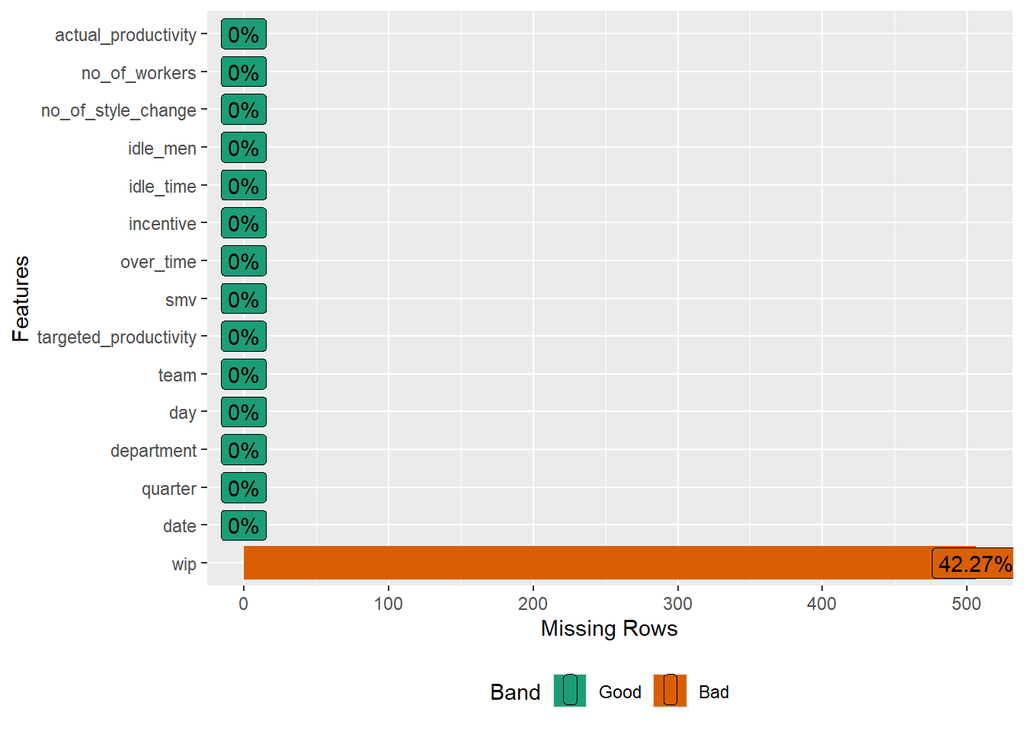

```r
plot_missing(garment_df)
```

Only the variable wip (Work in Progress) contains missing values, with a total of 506 missing observations. This variable represents the number of items in the production process, including those that are not yet completed.

Additionally, imputing these missing values using measures such as the median could distort the original distribution of wip, artificially accumulating observations at a single point. Such an approach would be particularly harmful in a classification context, as it could introduce bias and undermine the model’s predictive capacity.

For these reasons, a more robust imputation strategy was chosen: predicting the missing wip values using a regression model that leverages other available variables as predictors. This approach helps preserve the natural variability and structure of the data. Furthermore, an indicator variable (wip_missing) was added to flag which observations were imputed, allowing the final model to account for this condition and correct for potential biases.

This solution aims to strike a balance between retaining relevant information and avoiding the introduction of noise or excessive simplifications in the modelling process.

```r
# New variable
garment_df$wip_missing <- is.na(garment_df$wip)
```

##### 2.0.2.3.1 Imputation

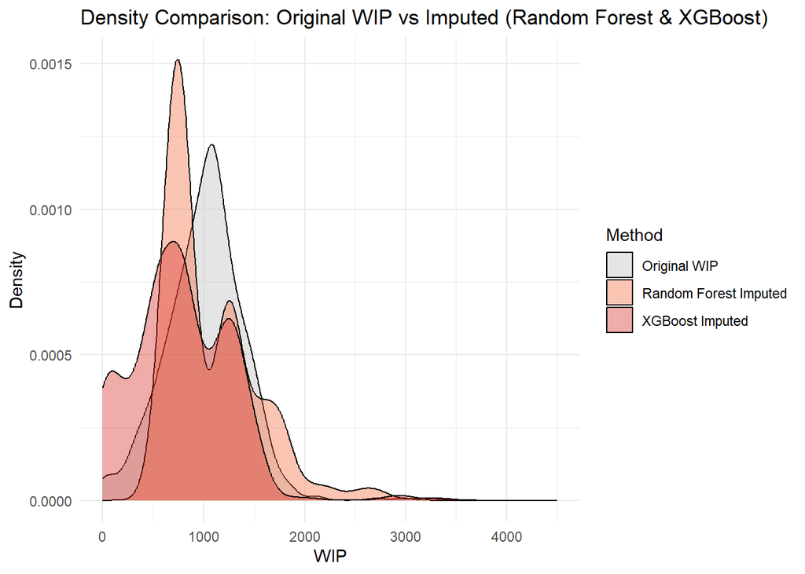

```r
set.seed(123)

# Divide in train y test
train_data <- garment_df %>% filter(!is.na(wip))
test_data <- garment_df %>% filter(is.na(wip))

# Selection of predictors
predictors <- c("team", "targeted_productivity", "smv", "over_time", "incentive",
                "idle_time", "idle_men", "no_of_style_change", "no_of_workers",
                "actual_productivity")

# Random Forest
rf_model <- randomForest(
  x = train_data[, predictors],
  y = train_data$wip,
  ntree = 100
)

## RF predictions
rf_pred <- predict(rf_model, newdata = test_data[, predictors])

# XGBoost
dtrain <- xgb.DMatrix(data = as.matrix(train_data[, predictors]), label = train_data$wip)
dtest <- xgb.DMatrix(data = as.matrix(test_data[, predictors]))

xgb_model <- xgboost(
  data = dtrain,
  nrounds = 100,
  objective = "reg:squarederror",
  verbose = 0
)

## XGBoost predictions
xgb_pred <- predict(xgb_model, dtest)

# Since XGBoost can predict negative values, I am going to forbid that possibility
xgb_pred <- pmax(xgb_pred, 0)

# COMPARISON between original distribution, RF and XGBoost:
# Obtain the original values
wip_original <- garment_df$wip[!is.na(garment_df$wip)]

# Merge the imputed values with the original ones
all_wip <- c(wip_original, rf_pred, xgb_pred)

# Create a vector with the methods
methods <- c(rep("Original WIP", length(wip_original)),
             rep("Random Forest Imputed", length(rf_pred)),
             rep("XGBoost Imputed", length(xgb_pred)))

# Create dataframe long
long_df <- data.frame(WIP = all_wip, Method = methods)

# Plot the density graph
ggplot(long_df, aes(x = WIP, fill = Method)) +
  geom_density(alpha = 0.4) +
  theme_minimal() +
  labs(
    title = "Density Comparison: Original WIP vs Imputed (Random Forest & XGBoost)",
    x = "WIP",
    y = "Density"
  ) +
  scale_fill_manual(values = c("grey", "#f46d43", "#d73027")) +
  xlim(0, 4500)
```

Comparing the imputed distributions with the original WIP values, the Random Forest imputation method demonstrates a greater ability to replicate the shape and dispersion of the original data. Therefore, Random Forest is selected as the most suitable imputation method to preserve the integrity of the variable.

```r
# Finally, imputation the NA with RF predictions
garment_df$wip[is.na(garment_df$wip)] <- rf_pred
```

#### 2.0.2.4 Distribution of the Variables

```r
# General distribution
summary(garment_df)
```

```
##      date             quarter           department            day
##  Length:1197        Length:1197        Length:1197        Length:1197
##  Class :character   Class :character   Class :character   Class :character
##  Mode  :character   Mode  :character   Mode  :character   Mode  :character
##
##
##
##       team        targeted_productivity      smv             wip
##  Min.   : 1.000   Min.   :0.0700        Min.   : 2.90   Min.   :    7.0
##  1st Qu.: 3.000   1st Qu.:0.7000        1st Qu.: 3.94   1st Qu.:  737.1
##  Median : 6.000   Median :0.7500        Median :15.26   Median :  992.0
##  Mean   : 6.427   Mean   :0.7296        Mean   :15.06   Mean   : 1137.4
##  3rd Qu.: 9.000   3rd Qu.:0.8000        3rd Qu.:24.26   3rd Qu.: 1273.2
##  Max.   :12.000   Max.   :0.8000        Max.   :54.56   Max.   :23122.0
##    over_time       incentive         idle_time           idle_men
##  Min.   :    0   Min.   :   0.00   Min.   :  0.0000   Min.   : 0.0000
##  1st Qu.: 1440   1st Qu.:   0.00   1st Qu.:  0.0000   1st Qu.: 0.0000
##  Median : 3960   Median :   0.00   Median :  0.0000   Median : 0.0000
##  Mean   : 4567   Mean   :  38.21   Mean   :  0.7302   Mean   : 0.3693
##  3rd Qu.: 6960   3rd Qu.:  50.00   3rd Qu.:  0.0000   3rd Qu.: 0.0000
##  Max.   :25920   Max.   :3600.00   Max.   :300.0000   Max.   :45.0000
##  no_of_style_change no_of_workers   actual_productivity wip_missing
##  Min.   :0.0000     Min.   : 2.00   Min.   :0.2337      Mode :logical
##  1st Qu.:0.0000     1st Qu.: 9.00   1st Qu.:0.6503      FALSE:691
##  Median :0.0000     Median :34.00   Median :0.7733      TRUE :506
##  Mean   :0.1504     Mean   :34.61   Mean   :0.7351
##  3rd Qu.:0.0000     3rd Qu.:57.00   3rd Qu.:0.8503
##  Max.   :2.0000     Max.   :89.00   Max.   :1.1204
```

```r
descr(garment_df, stats = "common")
```

```
## Non-numerical variable(s) ignored: date, quarter, department, day, wip_missing
```

```
## Descriptive Statistics
## garment_df
## N: 1197
##
##                   actual_productivity   idle_men   idle_time   incentive   no_of_style_change
## --------------- --------------------- ---------- ----------- ----------- --------------------
##            Mean                  0.74       0.37        0.73       38.21                 0.15
##         Std.Dev                  0.17       3.27       12.71      160.18                 0.43
##             Min                  0.23       0.00        0.00        0.00                 0.00
##          Median                  0.77       0.00        0.00        0.00                 0.00
##             Max                  1.12      45.00      300.00     3600.00                 2.00
##         N.Valid               1197.00    1197.00     1197.00     1197.00              1197.00
##               N               1197.00    1197.00     1197.00     1197.00              1197.00
##       Pct.Valid                100.00     100.00      100.00      100.00               100.00
##
## Table: Table continues below
##
##
##
##                   no_of_workers   over_time       smv   targeted_productivity      team        wip
## --------------- --------------- ----------- --------- ----------------------- --------- ----------
##            Mean           34.61     4567.46     15.06                    0.73      6.43    1137.44
##         Std.Dev           22.20     3348.82     10.94                    0.10      3.46    1428.15
##             Min            2.00        0.00      2.90                    0.07      1.00       7.00
##          Median           34.00     3960.00     15.26                    0.75      6.00     992.00
##             Max           89.00    25920.00     54.56                    0.80     12.00   23122.00
##         N.Valid         1197.00     1197.00   1197.00                 1197.00   1197.00    1197.00
##               N         1197.00     1197.00   1197.00                 1197.00   1197.00    1197.00
##       Pct.Valid          100.00      100.00    100.00                  100.00    100.00     100.00
```

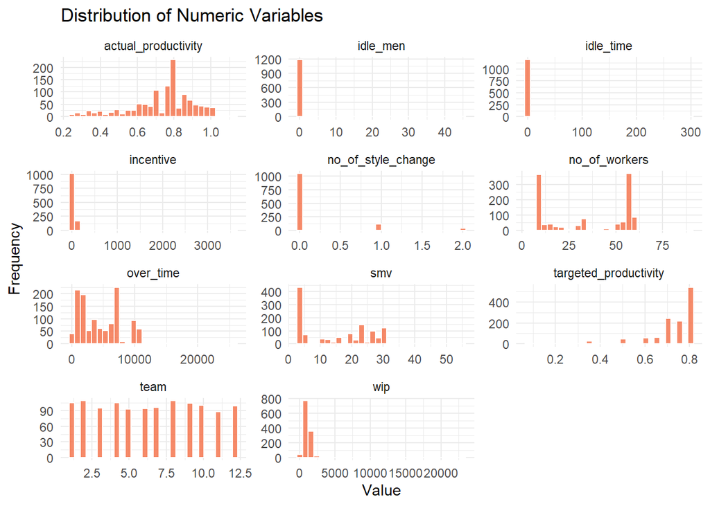

```r
# Convert to long format for numeric columns only
numeric_vars_long <- garment_df %>%
  dplyr::select(where(is.numeric)) %>%
  pivot_longer(cols = everything(), names_to = "variable", values_to = "value")

# Create the faceted histograms
ggplot(numeric_vars_long, aes(x = value)) +
  geom_histogram(fill = "#f46d43", color = "white", bins = 30, alpha = 0.8) +
  facet_wrap(~ variable, scales = "free", ncol = 3) +
  theme_minimal() +
  labs(
    title = "Distribution of Numeric Variables",
    x = "Value",
    y = "Frequency"
  )
```

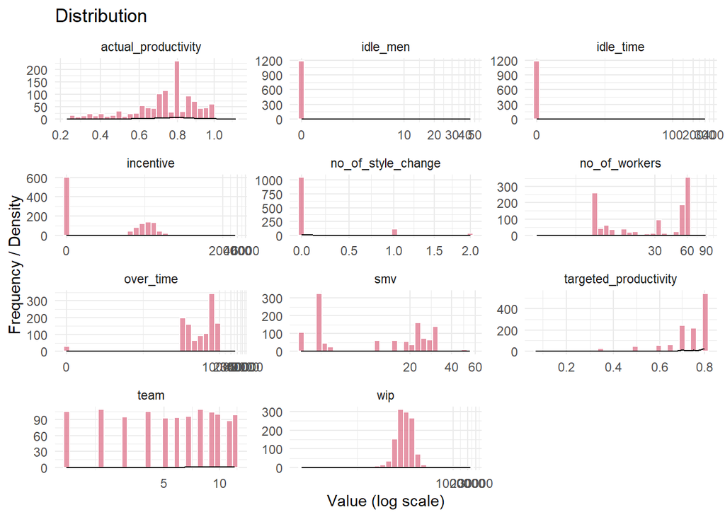

```r
# Plot with log-transformation
ggplot(numeric_vars_long, aes(x = value)) +
  geom_histogram(fill = "#e07b91", color = "white", bins = 30, alpha = 0.8) +
  geom_density(aes(y = ..density..), color = "black", size = 0.5) +
  facet_wrap(~ variable, scales = "free", ncol = 3) +
  scale_x_continuous(trans = "pseudo_log") +
  theme_minimal() +
  labs(
    title = "Distribution",
    x = "Value (log scale)",
    y = "Frequency / Density"
  )
```

The graphical and primary analysis of the dataset reveals high heterogeneity in the variables studied, with notable differences in their distributions and values. The team variable, although numeric, acts as a categorical identifier, displaying a fairly balanced distribution across the twelve teams (mean: 6.43, median: 6.00, range: 1–12). It is important to note that, although the plot displays teams numbered from 1 to 12, it is important to note that these are not unique teams across the entire factory; rather, each department (finishing and sewing) maintains its own set of 12 teams. Thus, the same team number in different departments does not necessarily refer to the same group of workers.

Regarding productivity, targeted_productivity is relatively uniform, ranging from 0.07 to 0.80 (mean: 0.73, median: 0.75), indicating that the targets set for teams are consistent throughout the dataset. It is important to note that the actual_productivity variable, as defined in the original study, is a computed index rather than a directly measured outcome. This index is inherently more variable than the target, with values spanning from 0.23 to 1.12 (mean: 0.74, median: 0.77). Such variability reflects genuine differences in team performance across different periods. A value of 1 indicates that the team precisely met the expected productivity target, while values greater than 1 signify over-productivity, or teams that have exceeded their goals. Conversely, values below 1 indicate underperformance.

Workload, as measured by smv (Standard Minute Value), ranges widely from 2.90 to 54.56 minutes (mean: 15.06, median: 15.26), capturing the diverse complexity of tasks. The over_time and incentive variables display highly right-skewed distributions: over_time ranges from 0 to 25,920 minutes (mean: 4,567, median: 3,960), and incentive ranges from 0 to 3,600 (mean: 38.2, median: 0), illustrating that most workers do not receive incentives, while a few receive substantial amounts.

Concerning inefficiencies and team structure, both idle_time and idle_men are heavily zero-inflated (mean idle_time: 0.73, median: 0; mean idle_men: 0.37, median: 0), indicating that most teams rarely experience idleness, but when they do, it can be significant (maximum idle_time: 300, maximum idle_men: 45). The no_of_style_change variable is also mostly zero (mean: 0.15, max: 2), while no_of_workers varies broadly from 2 to 89 (mean: 34.6, median: 34), showing large differences in team sizes.

The wip (Work in Progress) variable, after successful imputation, now ranges from 7 to 23,122 (mean: 1,137, median: 992), capturing substantial variability in the volume of ongoing work across teams and time periods.

Faceted histograms, both in their original and log-transformed forms, reinforce the diversity and dispersion in the data: some variables cluster within narrow ranges, while others display pronounced outliers and skewness. These graphical representations offer a clear view of the density and frequency of values, establishing a robust foundation for subsequent analytical stages such as feature selection and explanatory modelling.

### 2.0.3 Bivariate and Relationship Analysis

In this section, I will delve deeper into the relationships between the different variables, examining how they interact and correlate with each other. The main focus will be on exploring how these variables influence or are associated with both actual productivity and targeted productivity, which are central to the study. By understanding these relationships, we can begin to identify which factors have the greatest impact on productivity levels, uncover potential patterns, and inform the next stages of modelling and analysis.

#### 2.0.3.1 Evolution

First, we will examine the evolution of productivity, assessing whether any trend or seasonal pattern emerges. This analysis will provide a broader temporal context for understanding the fluctuations in both actual and targeted productivity over time.

```r
# Convert the date into MDY model
garment_df <- garment_df %>%
  mutate(date = mdy(date))
```

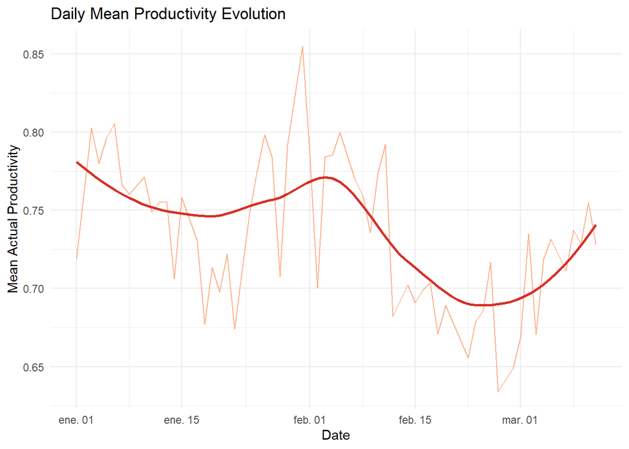

```r
#Daily Productivity Evolution
df_daily <- garment_df %>%
  group_by(date) %>%
  summarise(mean_productivity = mean(actual_productivity, na.rm = TRUE))
ggplot(df_daily, aes(x = date, y = mean_productivity)) +
  geom_line(color = "#fc8d59", alpha = 0.7) +
  geom_smooth(method = "loess", se = FALSE, color = "#d73027") +
  labs(
    title = "Daily Mean Productivity Evolution",
    x = "Date", y = "Mean Actual Productivity"
  ) +
  theme_minimal()
```

The daily evolution of actual productivity shows a relatively stable trend throughout the first half of the analyzed period, with minor fluctuations and some notable peaks. However, from early February onwards, there is a progressive decline coinciding with the absence of the high values seen in previous weeks. This downward trend continues until late February, when productivity reaches its lowest point in the period. From March onwards, a moderate recovery can be observed, although the daily mean productivity does not fully return to the initial high levels. The smoothed trend line highlights these changes and reveals the presence of short cycles and day-to-day variability.

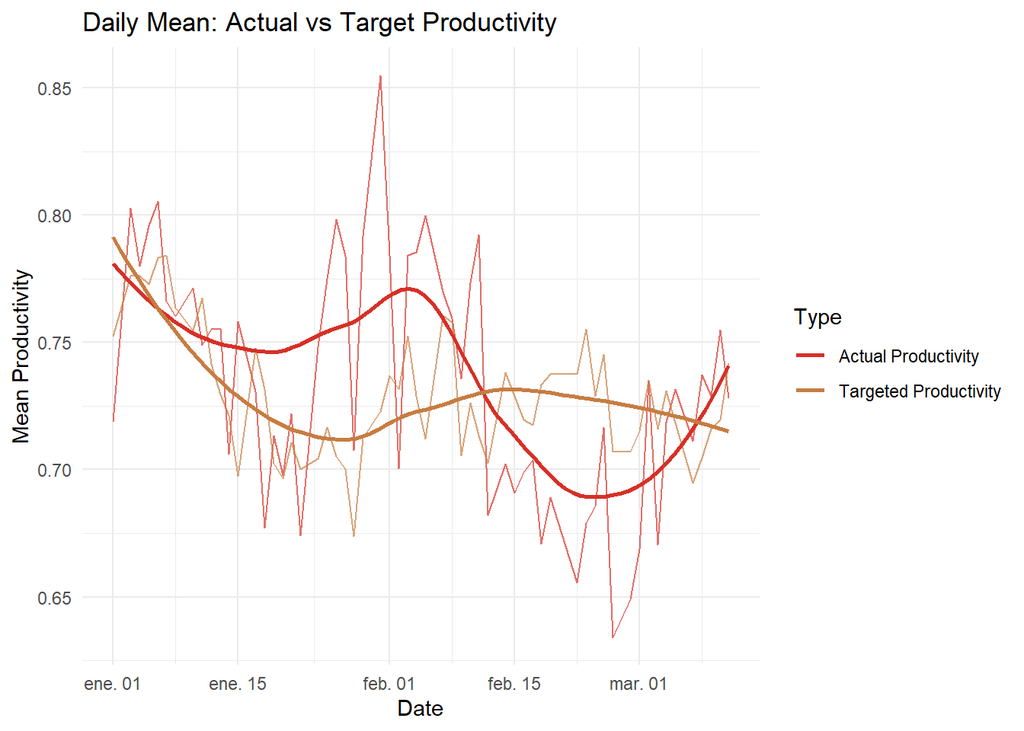

```r
# Mean Actual vs Target productivity
df_long_mean <- garment_df %>%
  dplyr::select(date, actual_productivity, targeted_productivity) %>%
  pivot_longer(cols = c(actual_productivity, targeted_productivity),
               names_to = "type", values_to = "value") %>%
  group_by(date, type) %>%
  summarise(mean_value = mean(value, na.rm = TRUE), .groups = "drop")

ggplot(df_long_mean, aes(x = date, y = mean_value, color = type)) +
  geom_line(alpha = 0.7) +
  geom_smooth(se = FALSE) +
  scale_color_manual(
    values = c(
      "actual_productivity" = "#d73027",
      "targeted_productivity" = "#c77d42"
    ),
    labels = c("Actual Productivity", "Targeted Productivity")
  ) +
  labs(
    title = "Daily Mean: Actual vs Target Productivity",
    x = "Date", y = "Mean Productivity", color = "Type"
  ) +
  theme_minimal()
```

The joint analysis of actual and target productivity shows that both variables follow similar trends over time, but with marked differences in volatility. Actual productivity demonstrates greater fluctuations, especially in the first third of the period, with several days where it temporarily exceeds the target productivity. Subsequently, from February onwards, actual productivity falls below the set target and maintains a constant gap for several weeks, before beginning a modest recovery in March. In contrast, target productivity remains much more stable and linear, reflecting its planned and less reactive nature.

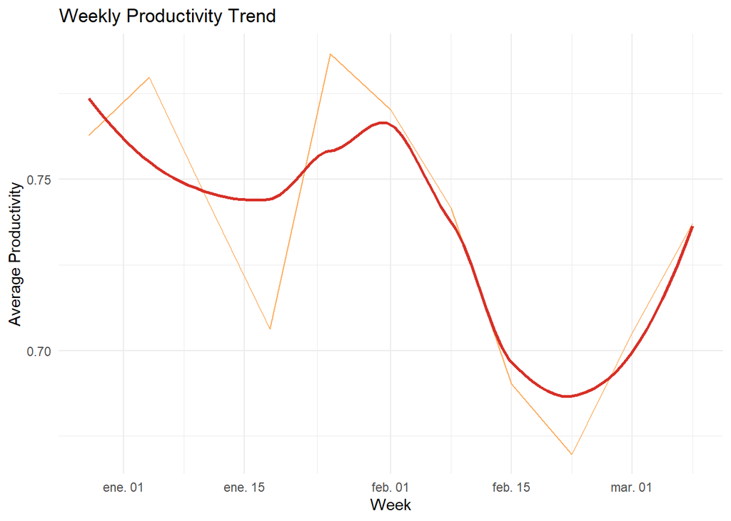

```r
# Weekly Productivity Trend
summary_week <- garment_df %>%
  mutate(week = floor_date(date, "week")) %>%
  group_by(week) %>%
  summarise(weekly_prod = mean(actual_productivity, na.rm = TRUE))

ggplot(summary_week, aes(x = week, y = weekly_prod)) +
  geom_line(color = "#fdae61") +
  geom_smooth(method = "loess", se = FALSE, color = "#d73027") +
  labs(
    title = "Weekly Productivity Trend",
    x = "Week", y = "Average Productivity"
  ) +
  theme_minimal()
```

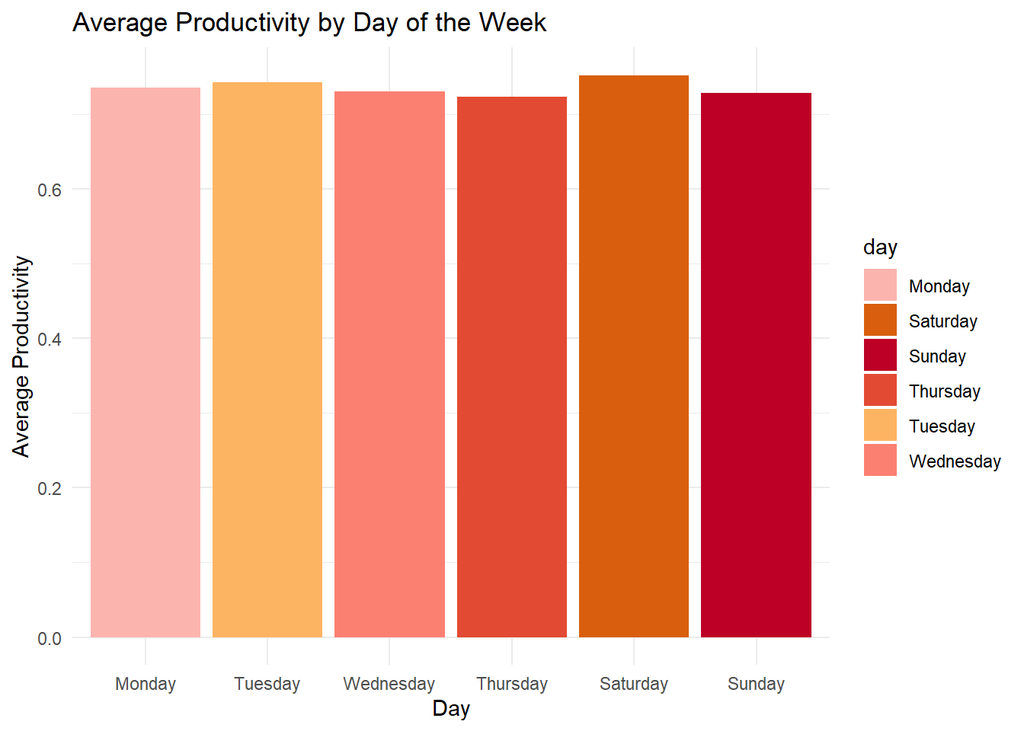

```r
# Average Productivity by Day
garment_df %>%
  group_by(day) %>%
  summarise(avg_prod = mean(actual_productivity, na.rm = TRUE)) %>%
  ggplot(aes(x = factor(day, levels = c("Monday", "Tuesday", "Wednesday", "Thursday", "Saturday", "Sunday")),
             y = avg_prod, fill = day)) +
  geom_col() +
  labs(title = "Average Productivity by Day of the Week",
       x = "Day", y = "Average Productivity") +
  scale_fill_manual(values = my_palette) +
  theme_minimal()
```

When analyzing mean productivity by day of the week, there is notable consistency across workdays, with minimal variations between different days. No significant drops are associated with any specific day. The absence of data for Fridays stands out, suggesting that the factory might not operate on that day, or simply that no records are available for Fridays.

Taken together, the temporal analyses indicate that actual productivity is more volatile than target productivity, with a marked downward cycle starting in February and a gradual recovery in March. Target productivity serves as a stable benchmark, whereas actual performance is more variable, possibly affected by operational, seasonal, or internal organizational factors. The stability of productivity across days of the week, and the absence of data for Fridays, reinforce the importance of contextualizing the results within the factory’s work calendar.

#### 2.0.3.2 Organizational factors

This part examines how organizational structure and departmental differences influence productivity outcomes. By comparing departments and analyzing team-level metrics, the analysis highlights the impact of team size, work organization, and operational consistency on performance.

Difference between department:

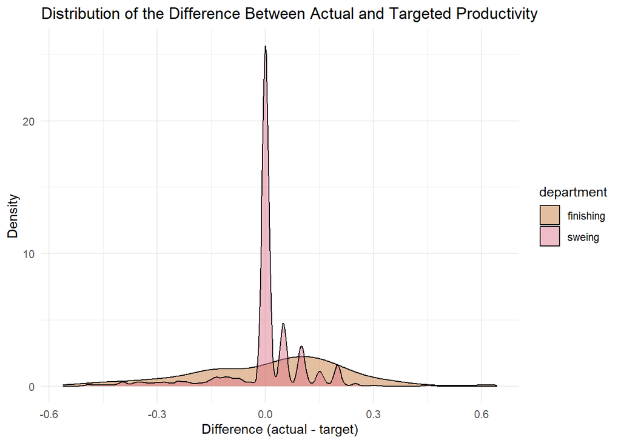

```r
#Distribution of the Difference between actual and targeted productivity by department
garment_df %>%
  mutate(diff_productivity = actual_productivity - targeted_productivity) %>%
  ggplot(aes(x = diff_productivity, fill = department)) +
  geom_density(alpha = 0.5) +
  labs(title = "Distribution of the Difference Between Actual and Targeted Productivity",
       x = "Difference (actual - target)", y = "Density") +
  scale_fill_manual(values = my_palette) +
  theme_minimal()
```

```r
#Summary and table per department
department_summary <- garment_df %>%
  group_by(department) %>%
  summarise(
    avg_productivity = mean(actual_productivity, na.rm = TRUE),
    sd_productivity = sd(actual_productivity, na.rm = TRUE),
    avg_team_size = mean(no_of_workers, na.rm = TRUE),
    avg_overtime = mean(over_time, na.rm = TRUE),
    avg_idle_time = mean(idle_time, na.rm = TRUE),
    avg_incentive = mean(incentive, na.rm = TRUE),
    avg_smv = mean(smv, na.rm = TRUE),
    n_obs = n()
  ) %>%
  mutate(across(where(is.numeric), ~ round(.x, 2)))

department_table <- flextable(department_summary) %>%
  set_header_labels(
    department = "Department",
    avg_productivity = "Avg. Productivity",
    sd_productivity = "SD Productivity",
    avg_team_size = "Avg. Team Size",
    avg_overtime = "Avg. Overtime",
    avg_idle_time = "Avg. Idle Time",
    avg_incentive = "Avg. Incentive",
    avg_smv = "Avg. SMV",
    n_obs = "N Obs."
  ) %>%
  add_header_lines("Department Comparative Table") %>%
  bold(i = 1, part = "header") %>%
  color(i = 1, part = "header", color = "black") %>%
  autofit() %>%
  theme_box() %>%
  align(align = "center", part = "all")


department_table
```

| Department Comparative Table Department | Department Comparative Table Avg. Productivity | Department Comparative Table SD Productivity | Department Comparative Table Avg. Team Size | Department Comparative Table Avg. Overtime | Department Comparative Table Avg. Idle Time | Department Comparative Table Avg. Incentive | Department Comparative Table Avg. SMV | Department Comparative Table N Obs. |
| --- | --- | --- | --- | --- | --- | --- | --- | --- |
| finishing | 0.75 | 0.20 | 10.25 | 1,917.15 | 0.00 | 29.64 | 3.89 | 506 |
| sweing | 0.72 | 0.15 | 52.45 | 6,508.21 | 1.26 | 44.48 | 23.25 | 691 |

The combined analysis of productivity and the distribution of differences between actual and targeted productivity reveals distinct patterns across the two departments.

The sewing department displays a slightly lower average productivity level compared to finishing (0.72 vs. 0.75), but with less variability in its results, the standard deviation of 0.15 vs. 0.20. This is clearly illustrated in the density plot, where the distribution of the difference between actual and targeted productivity is sharply centered around zero for sewing. Such concentration suggests that, in most cases, actual performance closely matches the set targets. Additionally, the sewing department operates with substantially larger teams (an average of 52 workers versus 10 in finishing), more overtime hours, and higher average incentives, indicating a more homogeneous and stable work organization. This structural uniformity likely contributes to the reduced variability observed in their productivity outcomes.

In contrast, the finishing department achieves a marginally higher mean productivity, but with significantly greater dispersion. The distribution of the productivity difference for finishing is broader and flatter, indicating a wider range of outcomes relative to targets. This greater variability may reflect the inherently more variable or less predictable nature of finishing tasks, or could point to less standardized workflows.

Overall, these results suggest that working conditions and organizational structure directly influence productivity variability. While sewing appears to operate within a more mechanized and less variable framework, finishing faces greater challenges in maintaining consistent and efficient output.

Difference between teams:

```r
# Average productivity by team
team_dept_summary <- garment_df %>%
  group_by(department, team) %>%
  summarise(
    avg_productivity = mean(actual_productivity, na.rm = TRUE),
    sd = sd(actual_productivity, na.rm = TRUE),
    n = n()
  )
```

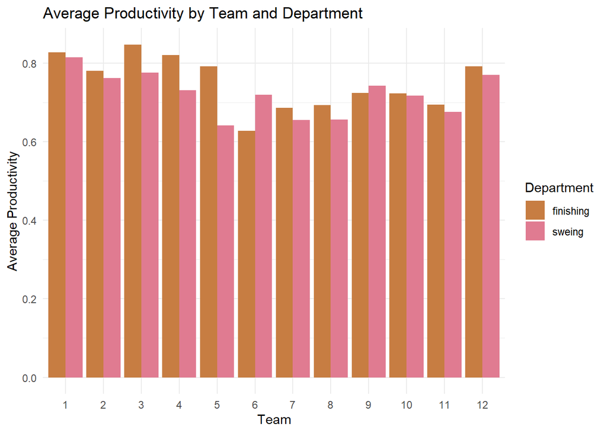

```r
ggplot(team_dept_summary, aes(x = factor(team), y = avg_productivity, fill = department)) +
  geom_bar(stat = "identity", position = "dodge") +
  scale_fill_manual(values = my_palette) +
  labs(
    title = "Average Productivity by Team and Department",
    x = "Team",
    y = "Average Productivity",
    fill = "Department"
  ) +
  theme_minimal()
```

For most team numbers the finishing department tends to have slightly higher average productivity than the sewing department. However, the productivity gap between departments varies depending on the team, suggesting that not all differences can be explained solely by departmental factors. Some teams within each department perform significantly better than others, highlighting substantial internal variability.

```r
summary_by_team_dept <- garment_df %>%
  group_by(department, team) %>%
  summarise(
    avg_productivity = mean(actual_productivity, na.rm = TRUE),
    sd_productivity = sd(actual_productivity, na.rm = TRUE),
    avg_team_size = mean(no_of_workers, na.rm = TRUE),
    avg_overtime = mean(over_time, na.rm = TRUE),
    avg_idle_time = mean(idle_time, na.rm = TRUE),
    avg_incentive = mean(incentive, na.rm = TRUE),
    avg_smv = mean(smv, na.rm = TRUE),
    .groups = "drop"
  ) %>%
  mutate(across(where(is.numeric), ~ round(.x, 2)))

team_dept_table <- flextable(summary_by_team_dept) %>%
  set_header_labels(
    department = "Department",
    team = "Team",
    avg_productivity = "Avg. Productivity",
    sd_productivity = "SD Productivity",
    avg_team_size = "Avg. Team Size",
    avg_overtime = "Avg. Overtime",
    avg_idle_time = "Avg. Idle Time",
    avg_incentive = "Avg. Incentive",
    avg_smv = "Avg. SMV"
  ) %>%
  add_header_lines("Team and Department Comparative Table") %>%
  bold(i = 1, part = "header") %>%
  color(i = 1, part = "header", color = "black") %>%
  autofit() %>%
  theme_box() %>%
  align(align = "center", part = "all")

team_dept_table
```

| Team and Department Comparative Table Department | Team and Department Comparative Table Team | Team and Department Comparative Table Avg. Productivity | Team and Department Comparative Table SD Productivity | Team and Department Comparative Table Avg. Team Size | Team and Department Comparative Table Avg. Overtime | Team and Department Comparative Table Avg. Idle Time | Team and Department Comparative Table Avg. Incentive | Team and Department Comparative Table Avg. SMV |
| --- | --- | --- | --- | --- | --- | --- | --- | --- |
| finishing | 1 | 0.83 | 0.15 | 9.67 | 1,888.16 | 0.00 | 19.59 | 3.94 |
| finishing | 2 | 0.78 | 0.20 | 11.67 | 1,983.46 | 0.00 | 23.08 | 4.05 |
| finishing | 3 | 0.85 | 0.15 | 12.24 | 2,774.59 | 0.00 | 38.92 | 4.40 |
| finishing | 4 | 0.82 | 0.17 | 13.46 | 2,758.70 | 0.00 | 20.87 | 4.18 |
| finishing | 5 | 0.79 | 0.18 | 9.74 | 2,115.43 | 0.00 | 82.29 | 4.17 |
| finishing | 6 | 0.63 | 0.23 | 9.00 | 1,527.43 | 0.00 | 0.00 | 2.93 |
| finishing | 7 | 0.69 | 0.19 | 9.93 | 1,896.59 | 0.00 | 0.00 | 3.84 |
| finishing | 8 | 0.69 | 0.17 | 9.08 | 1,581.51 | 0.00 | 18.11 | 3.77 |
| finishing | 9 | 0.72 | 0.20 | 8.87 | 1,260.00 | 0.00 | 78.26 | 3.63 |
| finishing | 10 | 0.72 | 0.22 | 10.37 | 2,009.30 | 0.00 | 22.33 | 3.65 |
| finishing | 11 | 0.69 | 0.23 | 9.31 | 1,651.03 | 0.00 | 33.10 | 3.62 |
| finishing | 12 | 0.79 | 0.17 | 9.18 | 1,588.50 | 0.00 | 27.00 | 4.34 |
| sweing | 1 | 0.82 | 0.16 | 57.24 | 7,335.54 | 0.00 | 70.23 | 25.37 |
| sweing | 2 | 0.76 | 0.19 | 55.56 | 6,575.79 | 0.11 | 52.02 | 24.30 |
| sweing | 3 | 0.78 | 0.13 | 56.92 | 7,035.00 | 0.00 | 56.34 | 25.56 |
| sweing | 4 | 0.73 | 0.14 | 57.49 | 7,547.80 | 2.54 | 46.10 | 26.82 |
| sweing | 5 | 0.64 | 0.13 | 57.27 | 7,271.38 | 1.69 | 29.14 | 26.70 |
| sweing | 6 | 0.72 | 0.12 | 34.76 | 4,461.61 | 0.00 | 36.17 | 17.24 |
| sweing | 7 | 0.65 | 0.17 | 57.35 | 7,064.18 | 5.20 | 27.11 | 27.95 |
| sweing | 8 | 0.66 | 0.18 | 56.60 | 6,896.79 | 5.60 | 31.29 | 27.13 |
| sweing | 9 | 0.74 | 0.13 | 56.10 | 7,103.79 | 0.00 | 47.19 | 24.90 |
| sweing | 10 | 0.72 | 0.18 | 54.10 | 6,794.21 | 0.28 | 46.89 | 23.10 |
| sweing | 11 | 0.68 | 0.13 | 53.20 | 5,665.42 | 0.07 | 40.27 | 15.81 |
| sweing | 12 | 0.77 | 0.08 | 33.92 | 4,490.42 | 0.00 | 50.83 | 14.83 |

The summary statistics by team and department reveal substantial heterogeneity in productivity, team size, workload, and incentive structures across the factory. Notably, teams within the finishing department are generally much smaller, typically comprising 9 to 13 workers, while teams in the sewing department are significantly larger, often exceeding 50 workers. Despite this difference in scale, the highest average productivity levels are not exclusively found in either department, but rather vary between specific teams.

Among both departments, the most productive teams tend to combine high or intermediate incentive levels, negligible idle time, and an effective balance between team size and task complexity (SMV). These teams are able to maintain high average productivity, which suggests a positive effect of adequate motivation and organizational efficiency.

Conversely, lower-performing teams often have lower average productivity despite sometimes having substantial team sizes or working longer overtime hours. These teams are also characterized by lower incentive averages, occasional idle time, and, in some cases, less complex tasks. This pattern indicates that neither increasing team size nor accumulating overtime alone is sufficient to drive productivity gains; rather, the alignment of incentives, efficient organization, and minimizing idle time appear to be more influential.

```r
# Count unique days per team and department
team_days <- garment_df %>%
  distinct(department, team, date) %>%
  count(department, team, name = "n_days")

# Check if all teams in each department appear the same number of days
check_equal_days <- team_days %>%
  group_by(department) %>%
  summarise(all_equal = length(unique(n_days)) == 1)

print(check_equal_days)
```

```
## # A tibble: 2 × 2
##   department all_equal
##   <chr>      <lgl>
## 1 finishing  FALSE
## 2 sweing     FALSE
```

```r
# Show teams with fewer days, if any
if (any(!check_equal_days$all_equal)) {
  cat("❌ Some teams are present fewer days than others within at least one department.\n")
  team_days %>%
    group_by(department) %>%
    arrange(n_days, .by_group = TRUE) %>%
    print()
} else {
  cat("✅ All teams are present the same number of days within each department.\n")
}
```

```
## ❌ Some teams are present fewer days than others within at least one department.
## # A tibble: 24 × 3
## # Groups:   department [2]
##    department  team n_days
##    <chr>      <dbl>  <int>
##  1 finishing     11     29
##  2 finishing      5     35
##  3 finishing      6     35
##  4 finishing      3     37
##  5 finishing     12     40
##  6 finishing      7     41
##  7 finishing     10     43
##  8 finishing      4     46
##  9 finishing      9     46
## 10 finishing      1     49
## # ℹ 14 more rows
```

The results reveal that not all teams have the same temporal coverage within the dataset. In the finishing department, the number of unique days on which each team appears ranges from as few as 29 (team 11) to 53 (team 8), indicating substantial variation in the data available for each group. Similarly, in the sewing department, most teams are present on 55 to 59 days, but there is still some variation, no team is represented on every possible day.

#### 2.0.3.3 Productivity gap

We are going to focus on the difference between actual productivity and the target productivity:

```r
# Create a productivity gap variable and performance groups
garment_df <- garment_df %>%
  mutate(
    productivity_gap = actual_productivity - targeted_productivity,
    perf_group = case_when(
      productivity_gap < -0.05 ~ "Below Target",
      abs(productivity_gap) <= 0.05 ~ "Meets Target",
      productivity_gap > 0.05 ~ "Exceeds Target"
    ),
    perf_group = factor(perf_group, levels = c("Below Target", "Meets Target", "Exceeds Target"))
  )

# Compare factors by performance group
summary_perf <- garment_df %>%
  group_by(perf_group) %>%
  summarise(
    avg_workers = mean(no_of_workers, na.rm = TRUE),
    avg_overtime = mean(over_time, na.rm = TRUE),
    avg_idle = mean(idle_time, na.rm = TRUE),
    avg_incentive = mean(incentive, na.rm = TRUE)
  )%>%
  mutate(across(where(is.numeric), ~ round(.x, 2)))

perf_table <- flextable(summary_perf) %>%
  set_header_labels(
    perf_group = "Performance Group",
    avg_workers = "Avg. Team Size",
    avg_overtime = "Avg. Overtime",
    avg_idle = "Avg. Idle Time",
    avg_incentive = "Avg. Incentive"
  ) %>%
  add_header_lines("Comparative Table by Performance Group") %>%
  bold(i = 1, part = "header") %>%
  color(i = 1, part = "header", color = "black") %>%
  autofit() %>%
  theme_box() %>%
  align(align = "center", part = "all")

perf_table
```

| Comparative Table by Performance Group Performance Group | Comparative Table by Performance Group Avg. Team Size | Comparative Table by Performance Group Avg. Overtime | Comparative Table by Performance Group Avg. Idle Time | Comparative Table by Performance Group Avg. Incentive |
| --- | --- | --- | --- | --- |
| Below Target | 24.86 | 3,471.24 | 1.32 | 10.99 |
| Meets Target | 43.76 | 5,380.97 | 1.05 | 42.63 |
| Exceeds Target | 30.08 | 4,307.19 | 0.00 | 49.94 |

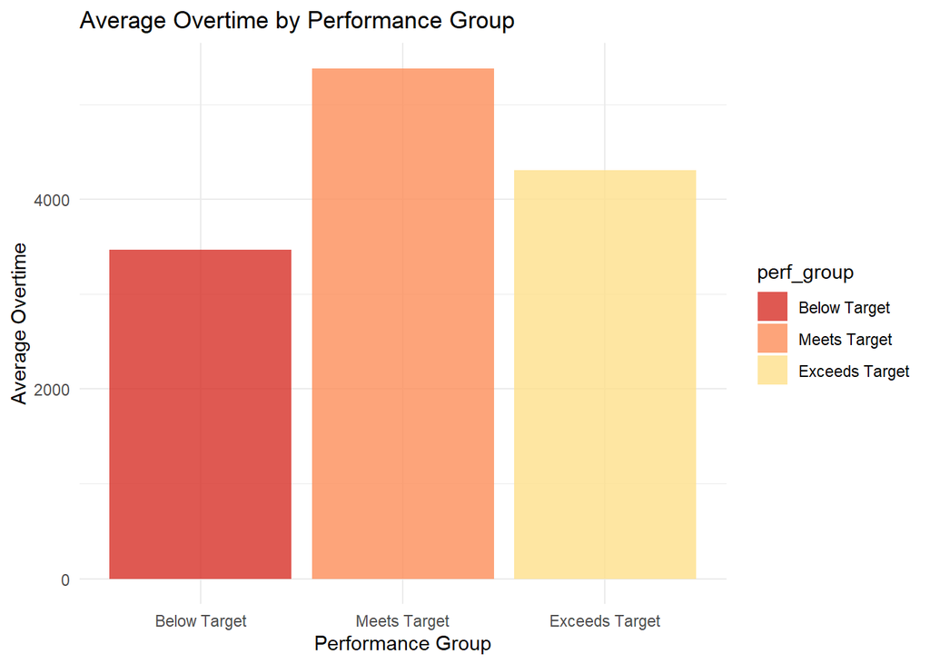

```r
# Average overtime by performance group
ggplot(summary_perf, aes(x = perf_group, y = avg_overtime, fill = perf_group)) +
  geom_col(alpha = 0.8) +
  labs(
    title = "Average Overtime by Performance Group",
    x = "Performance Group", y = "Average Overtime"
  ) +
  scale_fill_manual(values = my_palette) +
  theme_minimal()
```

Teams that exceed their productivity target are part of relatively small teams (averaging 30 members), register no idle time (0 minutes), and receive the highest average incentives (49.9 BDT). This suggests a strategy focused on efficiency and direct rewards for performance.

In contrast, those who do not meet the target belong to even smaller teams (24.8 members), exhibit the highest level of idle time (1.32 minutes), and receive very few incentives (10.9 BDT), which may reflect less favorable working conditions or a lack of structural motivation.

The group that meets the target works in significantly larger teams (43.7 members), performs more overtime on average (5,380 minutes), and receives moderate incentives (42.6 BDT). This group appears to operate under a logic of meeting goals through volume and time pressure rather than through genuine efficiency or bonus incentives.

```r
# ANOVA test
anova_result <- aov(actual_productivity ~ perf_group, data = garment_df)
summary(anova_result)
```

```
##               Df Sum Sq Mean Sq F value Pr(>F)
## perf_group     2  22.31  11.153   943.9 <2e-16 ***
## Residuals   1194  14.11   0.012
## ---
## Signif. codes:  0 '***' 0.001 '**' 0.01 '*' 0.05 '.' 0.1 ' ' 1
```

```r
# For comparison
TukeyHSD(anova_result)
```

```
##   Tukey multiple comparisons of means
##     95% family-wise confidence level
##
## Fit: aov(formula = actual_productivity ~ perf_group, data = garment_df)
##
## $perf_group
##                                  diff       lwr       upr p adj
## Meets Target-Below Target   0.2179118 0.1985640 0.2372597     0
## Exceeds Target-Below Target 0.3674596 0.3476026 0.3873166     0
## Exceeds Target-Meets Target 0.1495478 0.1327769 0.1663187     0
```

The ANOVA reveals significant differences in mean productivity across the performance groups: Below Target, Meets Target, and Exceeds Target (p-value < 2e-16). Post hoc comparisons confirm that each of these groups differs significantly from the others, with the largest difference between the Below Target and Exceeds Target groups. These results indicate that actual productivity increases as teams approach or exceed their targets.

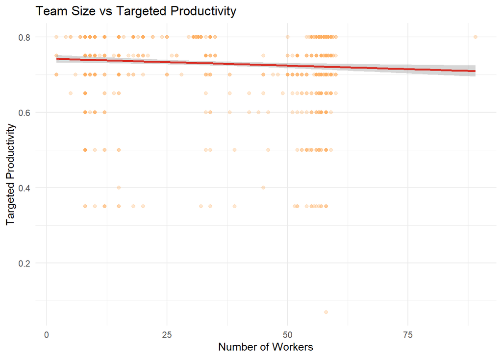

```r
#Relationship between number of workers and productivity
ggplot(garment_df, aes(x = no_of_workers, y = targeted_productivity)) +
  geom_point(alpha = 0.3, color = "#fdae61") +
  geom_smooth(method = "lm", color = "#d73027") +
  labs(title = "Team Size vs Targeted Productivity",
       x = "Number of Workers", y = "Targeted Productivity") +
  theme_minimal()
```

The graph shows a slight negative relationship between team size (no_of_workers) and targeted productivity (targeted_productivity). The regression line suggests that, as the number of workers increases, the expected productivity tends to decrease slightly.

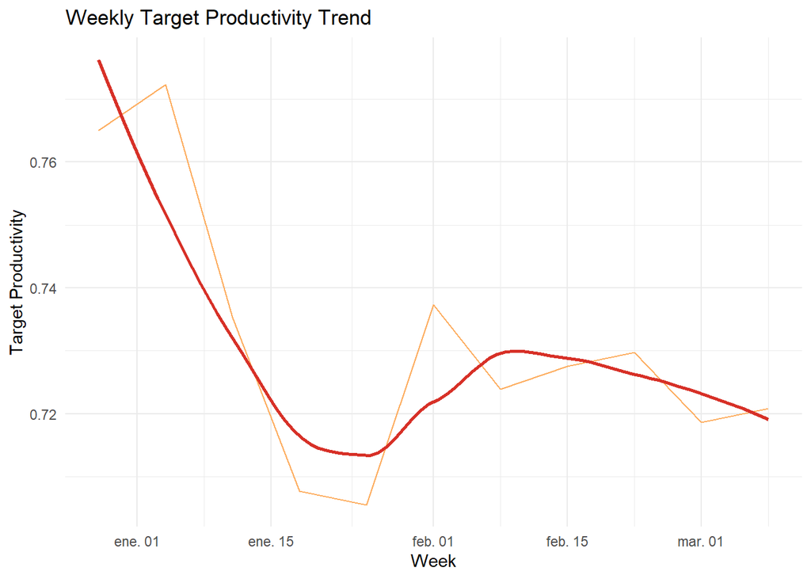

```r
target_week <- garment_df %>%
  mutate(week = floor_date(date, "week")) %>%
  group_by(week) %>%
  summarise(mean_target = mean(targeted_productivity, na.rm = TRUE))

ggplot(target_week, aes(x = week, y = mean_target)) +
  geom_line(color = "#fdae61") +
  geom_smooth(se = FALSE, color = "#d73027") +
  labs(title = "Weekly Target Productivity Trend",
       x = "Week", y = "Target Productivity") +
  theme_minimal()
```

This graph shows the weekly trend in targeted productivity. The following observations stand out:

- At the beginning of the period (early January), the targets were relatively high (around 0.77).
- Subsequently, there is a sustained decline until mid-January, followed by a slight recovery and stabilization in February.
- At the beginning of March, the targets again decrease slightly.
- This pattern suggests that the company adjusts its productivity goals over time, possibly based on observed performance, market conditions, or workforce changes.

#### 2.0.3.4 Extratime and incentive

Now, the relationship between Over Time per worker and productivity

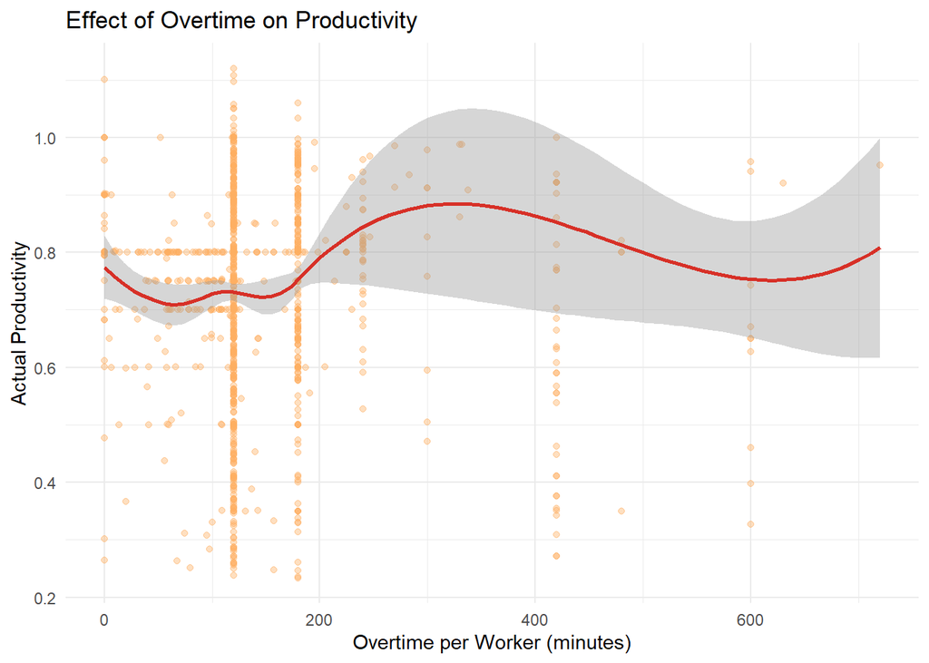

```r
garment_df <- garment_df %>%
  mutate(overtime_per_worker = over_time / no_of_workers)

# Productivity vs. Overtime per worker
ggplot(garment_df, aes(x = overtime_per_worker, y = actual_productivity)) +
  geom_point(alpha = 0.4, color = "#fdae61") +
  geom_smooth(method = "loess", color = "#d73027") +
  labs(
    title = "Effect of Overtime on Productivity",
    x = "Overtime per Worker (minutes)",
    y = "Actual Productivity"
  ) +
  theme_minimal()
```

In conclusion, a moderate level of overtime may improve productivity, but excessive overtime appears to have a limited or even negative impact.

For the incentive, we are going to divide the teams in groups.

```r
# Create incentive groups
garment_df <- garment_df %>%
  mutate(incentive_group = case_when(
    incentive == 0 ~ "No Incentive",
    incentive <= quantile(incentive[incentive > 0], 0.33, na.rm = TRUE) ~ "Low",
    incentive <= quantile(incentive[incentive > 0], 0.66, na.rm = TRUE) ~ "Medium",
    TRUE ~ "High"
  ),
  incentive_group = factor(incentive_group, levels = c("No Incentive", "Low", "Medium", "High"))
  )

# Compare average productivity by incentive group
garment_df %>%
  group_by(incentive_group) %>%
  summarise(
    avg_productivity = mean(actual_productivity, na.rm = TRUE),
    count = n()
  )
```

```
## # A tibble: 4 × 3
##   incentive_group avg_productivity count
##   <fct>                      <dbl> <int>
## 1 No Incentive               0.713   604
## 2 Low                        0.667   245
## 3 Medium                     0.784   168
## 4 High                       0.857   180
```

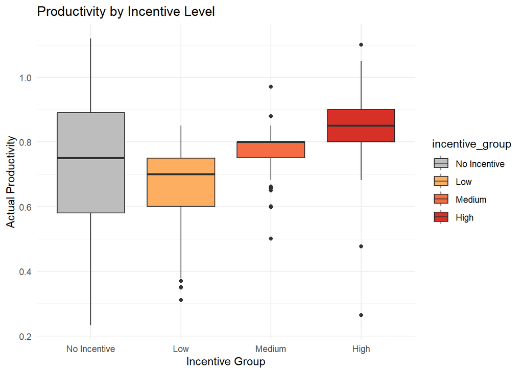

```r
# Boxplot of productivity by incentive group
ggplot(garment_df, aes(x = incentive_group, y = actual_productivity, fill = incentive_group)) +
  geom_boxplot() +
  labs(title = "Productivity by Incentive Level",
       x = "Incentive Group", y = "Actual Productivity") +
  scale_fill_manual(values = my_palette) +
  theme_minimal()
```

Economic incentives are clearly associated with better performance: the higher the incentive, the higher the average productivity. Interestingly, those who do not receive incentives have a higher average productivity than the low-incentive group but also show greater variability, including cases of very low performance.

However, we can do a t test to prove the relation:

```r
garment_df$has_incentive <- ifelse(garment_df$incentive > 0, "Yes", "No")
t.test(actual_productivity ~ has_incentive, data = garment_df)
```

```
##
##  Welch Two Sample t-test
##
## data:  actual_productivity by has_incentive
## t = -4.5612, df = 985.88, p-value = 5.726e-06
## alternative hypothesis: true difference in means between group No and group Yes is not equal to 0
## 95 percent confidence interval:
##  -0.06498499 -0.02588834
## sample estimates:
##  mean in group No mean in group Yes
##         0.7125815         0.7580182
```

There is a statistically significant difference in productivity between teams that do not receive incentives (0.712) and those who do (0.758). Teams who receive incentives exhibit significantly higher productivity compared to those without incentives.

## 2.1 Target variable

To carry out the classification exercise, the target variable **`achieves_target`** is defined as a binary indicator reflecting whether the work teams manage to reach or exceed the expected productivity. This classification allows for an explanatory approach, as it seeks to identify the factors associated with productive success.

To define the variable, a threshold of ± 0.05 was set for the difference between actual and targeted productivity. This margin is considered reasonable for determining whether a team has effectively met the expected productivity level, as small deviations may arise from normal operational fluctuations, measurement errors, or exceptional circumstances beyond the team’s control. Thus, teams whose actual productivity is less than 0.05 points below the target are classified as “achieving the target”. This approach avoids penalizing cases where the difference is minimal and operationally insignificant, resulting in a more realistic and robust analysis of productive success.

```r
# Create the binary variable
garment_df <- garment_df %>%
  mutate(
    productivity_gap = actual_productivity - targeted_productivity,
    achieves_target = ifelse(productivity_gap >= -0.05, 1, 0)
  )


# Frequency table
table(garment_df$achieves_target)
```

```
##
##   0   1
## 267 930
```

```r
# Percentage of each group
prop.table(table(garment_df$achieves_target)) * 100
```

```
##
##        0        1
## 22.30576 77.69424
```

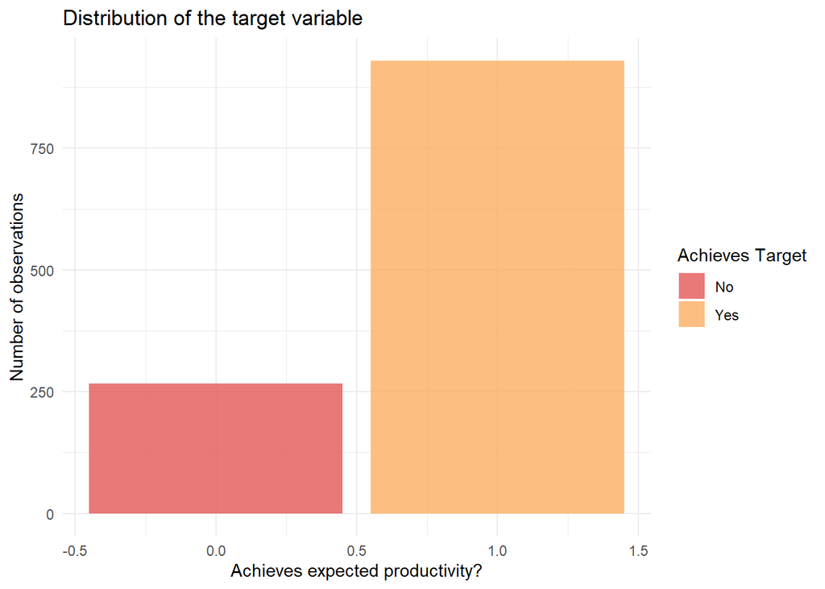

```r
# Graph
ggplot(garment_df, aes(x = achieves_target, fill = factor(achieves_target))) +
  geom_bar(alpha = 0.8) +
  labs(
    title = "Distribution of the target variable",
    x = "Achieves expected productivity?",
    y = "Number of observations"
  ) +
  scale_fill_manual(
    values = c("0" = "#e45756", "1" = "#fdae61"),
    labels = c("No", "Yes"),
    name = "Achieves Target"
  ) +
  theme_minimal()
```

The analysis of the objective variable reveals that 77.7% of the teams successfully achieved the expected productivity level, while 22.3% did not meet the target. This significant difference suggests that most teams were able to adapt their performance to reach the expected goals, although there is a notable group of teams whose productivity remained below expectations.

Now we can proceed to do an exploratory analysis of this variable:

```r
# T-test
t_test_workers <- t.test(no_of_workers ~ achieves_target, data = garment_df)
print(t_test_workers)
```

```
##
##  Welch Two Sample t-test
##
## data:  no_of_workers by achieves_target
## t = -8.2833, df = 423.93, p-value = 1.587e-15
## alternative hypothesis: true difference in means between group 0 and group 1 is not equal to 0
## 95 percent confidence interval:
##  -15.524552  -9.569806
## sample estimates:
## mean in group 0 mean in group 1
##        24.86142        37.40860
```

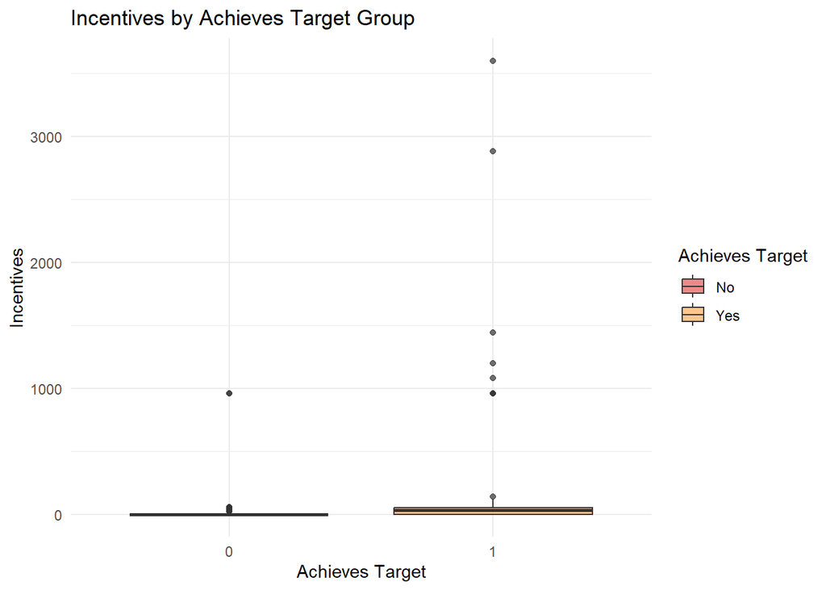

```r
# Boxplots for Incentive
ggplot(garment_df, aes(x = factor(achieves_target), y = incentive, fill = factor(achieves_target))) +
  geom_boxplot(alpha = 0.7) +
  labs(
    title = "Incentives by Achieves Target Group",
    x = "Achieves Target",
    y = "Incentives"
  ) +
  scale_fill_manual(
    values = c("0" = "#e45756", "1" = "#fdae61"),
    labels = c("No", "Yes"),
    name = "Achieves Target"
  ) +
  theme_minimal()
```

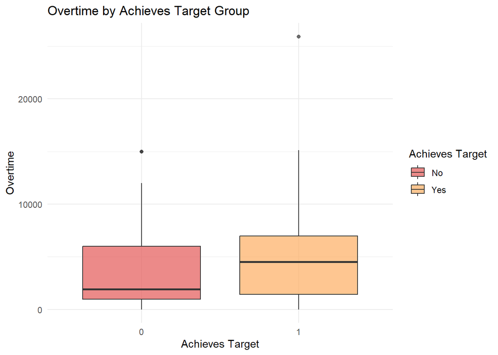

```r
# Boxplots for Over Time
ggplot(garment_df, aes(x = factor(achieves_target), y = over_time, fill = factor(achieves_target))) +
  geom_boxplot(alpha = 0.7) +
  labs(
    title = "Overtime by Achieves Target Group",
    x = "Achieves Target",
    y = "Overtime"
  ) +
  scale_fill_manual(
    values = c("0" = "#e45756", "1" = "#fdae61"),
    labels = c("No", "Yes"),
    name = "Achieves Target"
  ) +
  theme_minimal()
```

The t-test reveals a highly significant difference in the average number of workers between the two groups. Specifically, teams that met or exceeded their productivity targets had, on average, 37.4 workers, compared to 24.9 workers for teams that did not achieve their targets. This suggests that larger team sizes are strongly associated with meeting productivity expectations. Furthermore, these boxplots suggest that both incentives and overtime play a role in achieving productivity targets, but also highlight substantial variability within each group.

### 2.1.1 Correlations

Correlation Analysis to understand the relationship between numeric variables and productivity.

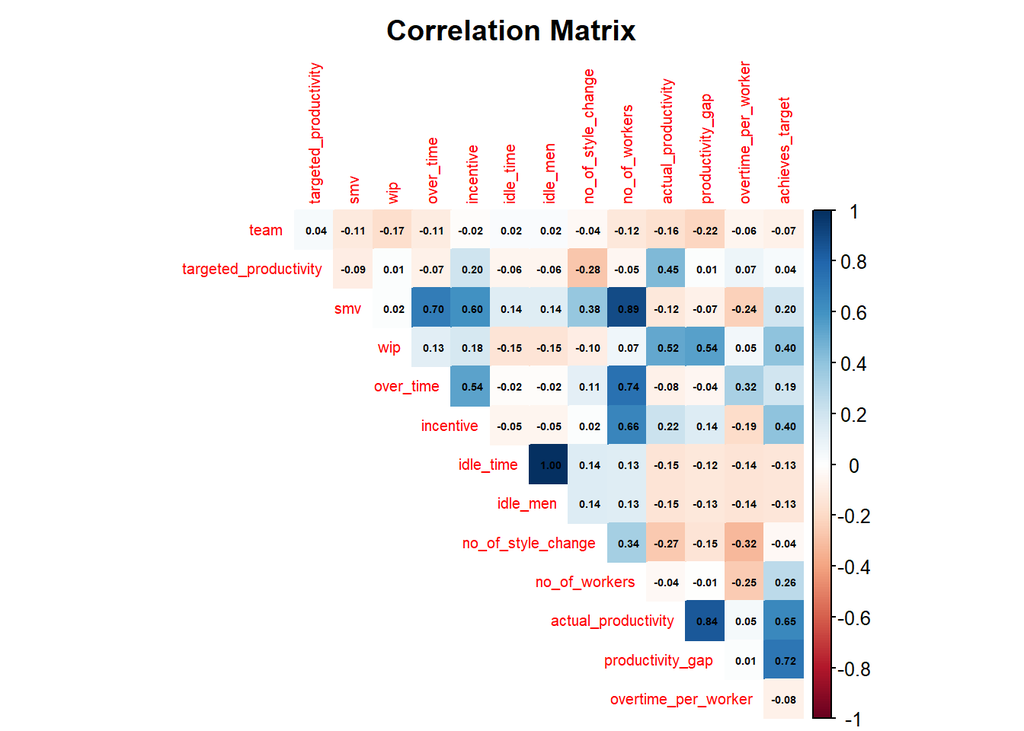

```r
# Select only numeric variables
num_vars <- garment_df %>%
  dplyr::select(where(is.numeric)) %>%
  drop_na()

# Compute correlation matrix
cor_matrix <- cor(num_vars, method = "spearman" , use = "complete.obs")

# Plot correlation matrix
corrplot(cor_matrix,
         method = "color",
         type = "upper",
         tl.cex = 0.62,
         number.cex = 0.45,
         addCoef.col = "black",
         title = "Correlation Matrix",
         mar = c(0, 0, 2, 0),
         diag = FALSE)
```

The correlation matrix reveals important relationships among the numeric variables in the dataset. Notably, there is a strong positive correlation between idle_time (downtime) and idle_men (number of idle workers during downtime), which is expected: the longer the downtime, the more workers are left inactive.

Both of these variables show a negative correlation with actual_productivity, indicating that production stoppages and staff inactivity have a negative impact on performance.

We also see a positive correlation between incentive and over_time, suggesting that teams who work more overtime tend to receive higher incentives. However, the correlation between over_time and actual_productivity is weak, reinforcing the idea that simply working longer hours does not necessarily lead to higher productivity.

Given the very high correlation between idle_time and idle_men (close to 1), keeping both variables in the analysis may cause multicollinearity problems in further steps. Since they both represent downtime and are closely related, we should remove one to avoid redundancy.

- Both variables capture the same phenomenon: downtime.
- idle_time measures the duration of the downtime in minutes, while idle_men counts the number of idle workers during that time.
- idle_time is a more direct, continuous measure of inefficiency, while idle_men depends on the size of the team and may introduce more noise.

Therefore, it is more robust and informative to keep idle_time and remove idle_men for subsequent analyses.

```r
garment_df <- garment_df %>%
  dplyr::select(-idle_men)
```

### 2.1.2 Bangladesh

To empirically contextualize the labour exploitation index proposed in this study, macroeconomic and labour indicators at the country level are incorporated. The aim is to analyse the structural evolution of Bangladesh in terms of recent labour conditions and productivity (since 1991/2008), and to compare it with other economies in the Global South and industrialized countries.

This approach allows for:

- Contrasting whether increases in productivity have been accompanied by improvements in labour conditions.
- Reinforcing the relevance of the custom-built metrics (exploitation index, idle ratio, surplus rate).
- Demonstrating that, despite economic growth, conditions linked to precarity and exploitation persist.

```r
countries <- c("BGD", "IND", "PAK", "VNM", "CHN",
               "DEU", "USA", "FRA", "ESP", "ITA")

# 1. ECONOMIC PRODUCTIVITY
gdp_productivity <- WDI(
  country = countries,
  indicator = "SL.GDP.PCAP.EM.KD",  # GDP per employed person (constant 2017 US$)
  start = 1991,
  end = 2023
)

# 2. VULNERABLE EMPLOYMENT (% of total employment)
vulnerable_employment <- WDI(
  country = countries,
  indicator = "SL.EMP.VULN.ZS",  # Vulnerable employment (% of total employment)
  start = 1991,
  end = 2023
)

# 3. TOTAL UNEMPLOYMENT (% of labour force)
unemployment <- WDI(
  country = countries,
  indicator = "SL.UEM.TOTL.ZS",  # Unemployment (% of total labour force)
  start = 1991,
  end = 2023
)

# 4. EXCESSIVE WORKING HOURS (weekly average)
excessive_hours <- WDI(
  country = countries,
  indicator = "JI.TLF.48UP.TM.ZS",
  start = 1991,
  end = 2023
)

# 5. AVERAGE WORKING HOURS (weekly average)
avg_hours <- WDI(
  country = countries,
  indicator = "JI.TLF.1564.WK.TM",  # Average weekly working hours, aged 15–64
  start = 2008,
  end = 2023
)
```

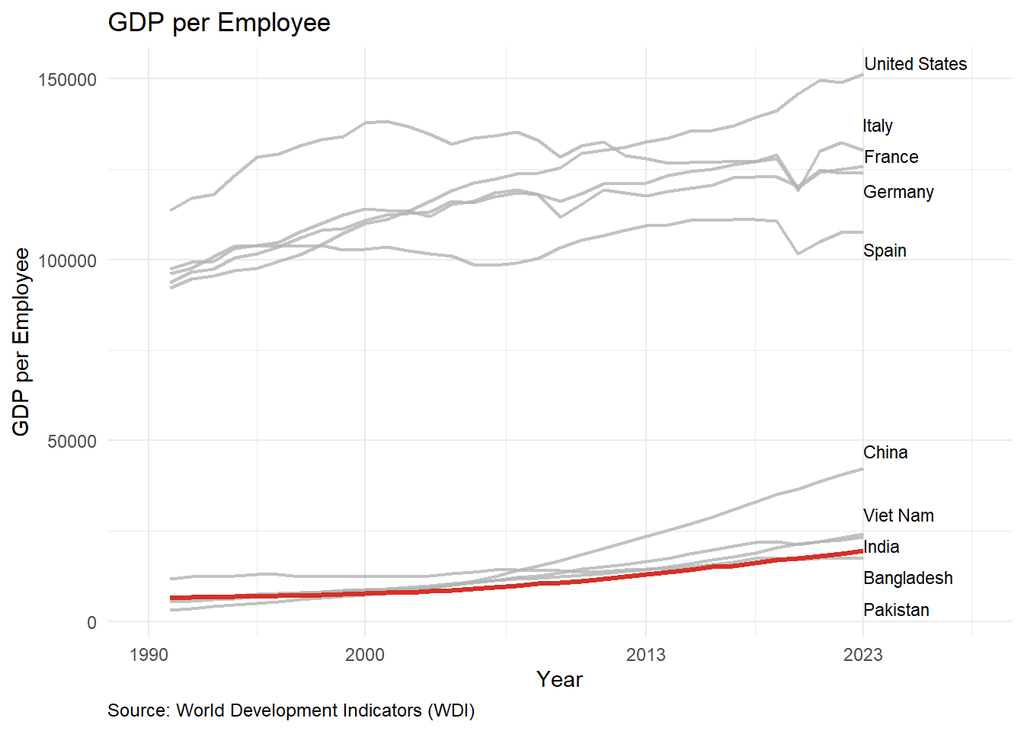

```r
# 1. ECONOMIC PRODUCTIVITY (since 1960)
latest_year <- max(gdp_productivity$year, na.rm = TRUE)

label_df <- gdp_productivity %>%
  filter(year == latest_year) %>%
  group_by(country) %>%
  summarise(
    year = max(year),
    gdp = SL.GDP.PCAP.EM.KD[which.max(year)]
  )

ggplot(gdp_productivity, aes(x = year, y = SL.GDP.PCAP.EM.KD, group = country)) +
  geom_line(data = filter(gdp_productivity, country != "Bangladesh"),
            color = "gray70", size = 0.8, alpha = 0.8) +
  geom_line(data = filter(gdp_productivity, country == "Bangladesh"),
            color = "#d73027", size = 1.2) +
  geom_text_repel(data = label_df,
                  aes(label = country, x = year, y = gdp),
                  size = 3, hjust = 0, direction = "y",
                  segment.color = NA,
                  box.padding = 0.3,
                  max.overlaps = Inf) +
  scale_x_continuous(limits = c(1990, latest_year + 5),
                     breaks = c(1990, 2000, 2013, 2023)) +
  labs(
    title = "GDP per Employee",
    x = "Year", y = "GDP per Employee",
    caption = "Source: World Development Indicators (WDI)"
  ) +
  theme_minimal() +
  theme(
    plot.caption = element_text(size = 9, hjust = 0),
    axis.title = element_text(size = 11),
    axis.text = element_text(size = 9)
  )
```

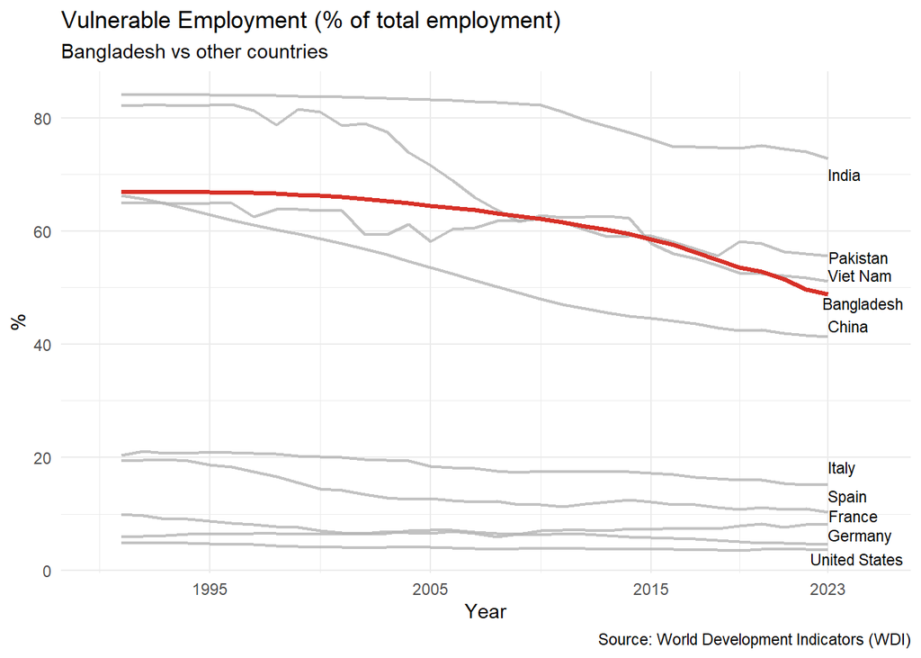

```r
# 2. VULNERABLE EMPLOYMENT (% of total employment)
label_vuln <- vulnerable_employment %>%
  group_by(country) %>%
  filter(year == max(year)) %>%
  ungroup()

ggplot(vulnerable_employment, aes(x = year, y = SL.EMP.VULN.ZS, group = country)) +
  geom_line(data = filter(vulnerable_employment, country != "Bangladesh"),
            color = "gray70", size = 0.8, alpha = 0.8) +
  geom_line(data = filter(vulnerable_employment, country == "Bangladesh"),
            color = "#d73027", size = 1.2) +
  geom_text_repel(data = label_vuln,
                  aes(label = country),
                  color = "black", size = 3, hjust = 0, direction = "y",
                  segment.color = NA, box.padding = 0.3, max.overlaps = Inf) +
  scale_x_continuous(limits = c(1990, 2025), breaks = c(1995, 2005, 2015, 2023)) +
  labs(
    title = "Vulnerable Employment (% of total employment)",
    subtitle = "Bangladesh vs other countries",
    x = "Year", y = "%",
    caption = "Source: World Development Indicators (WDI)"
  ) +
  theme_minimal()
```

Despite economic advances, the proportion of workers in vulnerable employment in Bangladesh remains among the highest globally, especially compared to industrialized economies. Although there has been a gradual reduction since the 1990s, the most recent figures still indicate widespread structural precariousness. This trend suggests that much of the workforce continues to operate in insecure, low-protection jobs.

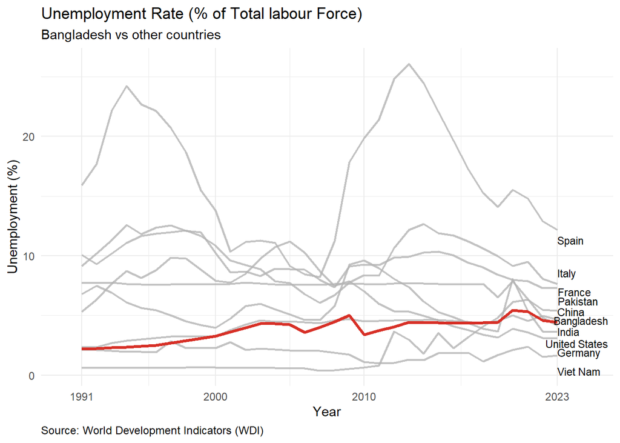

```r
# 3. TOTAL UNEMPLOYMENT (% of labour force)
label_df <- unemployment %>%
  group_by(country) %>%
  filter(year == max(year)) %>%
  ungroup()


ggplot(unemployment, aes(x = year, y = SL.UEM.TOTL.ZS, group = country)) +
  geom_line(data = filter(unemployment, country != "Bangladesh"),
            color = "gray70", size = 0.8, alpha = 0.8) +
  geom_line(data = filter(unemployment, country == "Bangladesh"),
            color = "#d73027", size = 1.2) +
  geom_text_repel(data = label_df,
                  aes(label = country),
                  size = 3, hjust = 0, direction = "y",
                  segment.color = NA,
                  box.padding = 0.3,
                  max.overlaps = Inf) +
  scale_x_continuous(limits = c(1990, 2025),
                     breaks = c(1991, 2000, 2010, 2023)) +
  labs(
    title = "Unemployment Rate (% of Total labour Force)",
    subtitle = "Bangladesh vs other countries",
    x = "Year", y = "Unemployment (%)",
    caption = "Source: World Development Indicators (WDI)"
  ) +
  theme_minimal() +
  theme(
    plot.caption = element_text(size = 9, hjust = 0),
    axis.title = element_text(size = 11),
    axis.text = element_text(size = 9)
  )
```

Bangladesh’s unemployment rate is relatively moderate and displays less volatility than in some European countries. However, this should be interpreted in light of the country’s high rate of vulnerable employment and informal labour, which can mask underlying underemployment or hidden unemployment.

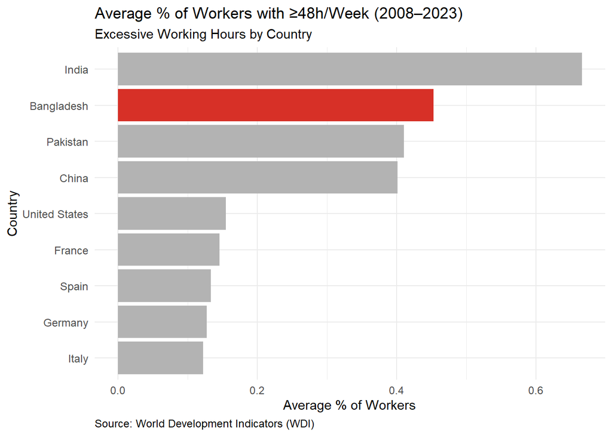

```r
# 4. EXCESSIVE WORKING HOURS (weekly, % working ≥48h/week)
excessive_hours_summary <- excessive_hours %>%
  group_by(country) %>%
  summarise(mean_excessive = mean(JI.TLF.48UP.TM.ZS, na.rm = TRUE)) %>%
  filter(!is.na(mean_excessive)) %>%
  mutate(color = ifelse(country == "Bangladesh", "#d73027", "gray70"))

ggplot(excessive_hours_summary, aes(x = reorder(country, mean_excessive), y = mean_excessive, fill = color)) +
  geom_col() +
  coord_flip() +
  labs(
    title = "Average % of Workers with ≥48h/Week (2008–2023)",
    subtitle = "Excessive Working Hours by Country",
    x = "Country",
    y = "Average % of Workers",
    caption = "Source: World Development Indicators (WDI)"
  ) +
  scale_fill_identity() +
  theme_minimal() +
  theme(
    plot.caption = element_text(size = 9, hjust = 0),
    axis.title = element_text(size = 11),
    axis.text = element_text(size = 9)
  )
```

Bangladesh is among the countries with the highest percentage of workers exceeding 48 hours per week, second only to India within the group analyzed. This prevalence of long working hours is not an isolated or short-term issue but reflects a persistent and systemic trait of the labour market.

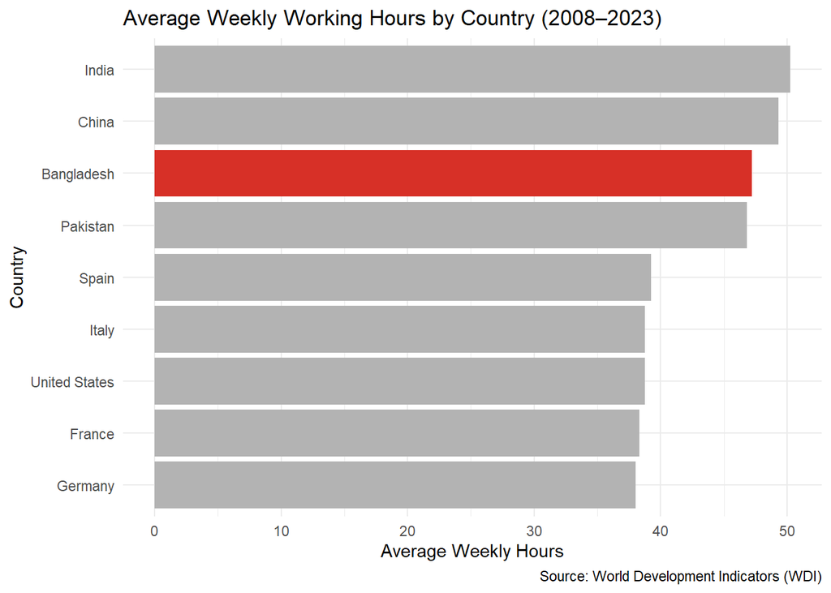

```r
# 5. AVERAGE WORKING HOURS (weekly average)
avg_hours_summary <- avg_hours %>%
  group_by(country) %>%
  summarise(mean_hours = mean(JI.TLF.1564.WK.TM, na.rm = TRUE)) %>%
  filter(!is.na(mean_hours)) %>%
  mutate(color = ifelse(country == "Bangladesh", "#d73027", "gray70"))


ggplot(avg_hours_summary, aes(x = reorder(country, mean_hours), y = mean_hours, fill = color)) +
  geom_col() +
  coord_flip() +
  labs(
    title = "Average Weekly Working Hours by Country (2008–2023)",
    x = "Country",
    y = "Average Weekly Hours",
    caption = "Source: World Development Indicators (WDI)"
  ) +
  scale_fill_identity() +
  theme_minimal()
```

The country also ranks among the global leaders in average weekly working hours, reinforcing the view that economic gains have come largely through intensive labour rather than improvements in job quality or working time reduction.

The analysis clearly demonstrates that Bangladesh’s economic growth has not been matched by a proportional improvement in labour conditions. Despite the increases in productivity, structural precariousness, intense productivity demands, and limited redistribution of value persist. The indicators developed in this study offer a sharper lens for understanding these internal tensions, revealing that the current growth model remains grounded in intensive, low-compensation labour.

Furthermore, comparative macro-level data reinforce these findings from a structural perspective, Bangladesh consistently registers some of the highest levels of vulnerable employment and average weekly working hours. The fact that excessive working time persists at such a scale confirms that these microlevel patterns are not isolated phenomena but rather part of a broader systemic reality.

### 2.1.3 Feature Engineering

1**.labour Exploitation Index:** Measures the degree to which work exceeds the normal planned time (normal_time). The index takes into account three factors:

- Overtime worked (over_time)
- Economic incentives, weighted (divided by 10 to align with other scales)
- Number of style changes, which add organizational and adaptive workload (weighted by 15)

This approach draws on established methodologies in the labour studies literature. For example, Chan and Siu (2010) examined the interaction of overtime and incentive systems in Chinese export factories as mechanisms of industrial exploitation, while Patnaik (1972) developed a composite index for class analysis in agriculture based on the balance of labour provided and received. Although the formula used here is original, it is directly inspired by these works, which combine workload, overtime, and compensation to operationalize exploitation.

This produces a proportion that reflects how much “extra” work is demanded of the worker compared to the planned work. The closer the index is to 1, the higher the degree of labour exploitation in terms of extra effort.

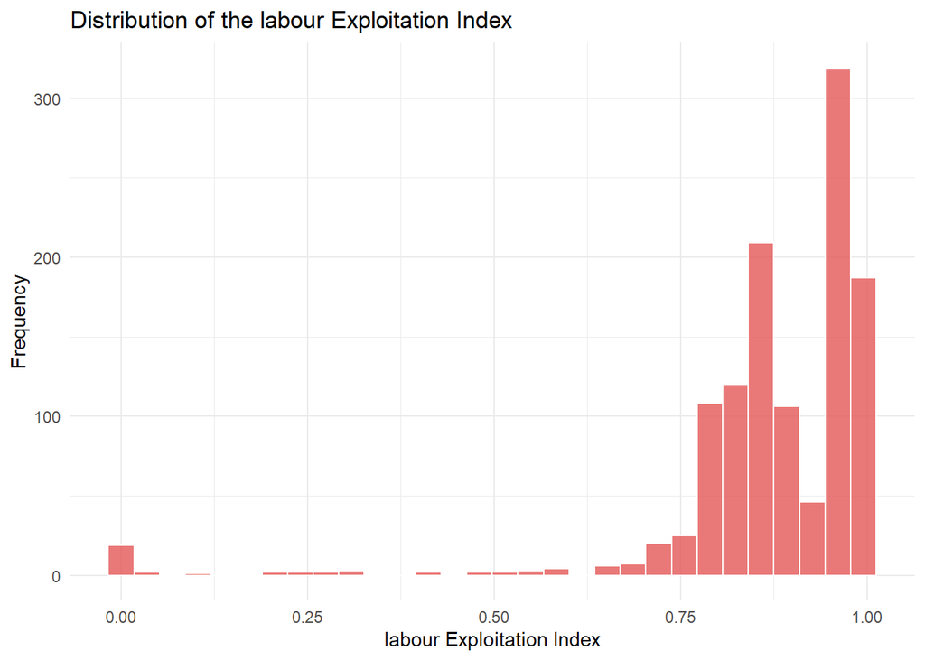

```r
garment_df <- garment_df %>%
  mutate(
    normal_time = smv * no_of_workers,
    labour_exploitation_index = (over_time + incentive/10 + no_of_style_change*15) /
                                (over_time + normal_time + incentive/10 + no_of_style_change*15)
  )


ggplot(garment_df, aes(x = labour_exploitation_index)) +
  geom_histogram(bins = 30, fill = "#e45756", color = "white", alpha = 0.8) +
  labs(
    title = "Distribution of the labour Exploitation Index",
    x = "labour Exploitation Index",
    y = "Frequency"
  ) +
  theme_minimal()
```

**2.Idle rate**

This metric represents the proportion of inactive time relative to the total time available for production, including:

- Idle time (`idle_time`)
- Normal time estimated for the task (`smv`)
- Overtime (`over_time`)

It serves as an indicator of temporal efficiency, useful for identifying bottlenecks, poor planning, or inefficient time management. This metric is widely recognized in industrial engineering and management accounting as a key indicator of resource utilization and operational efficiency. Ahn et al. (2013), for example, used the idle ratio to evaluate equipment performance in construction projects

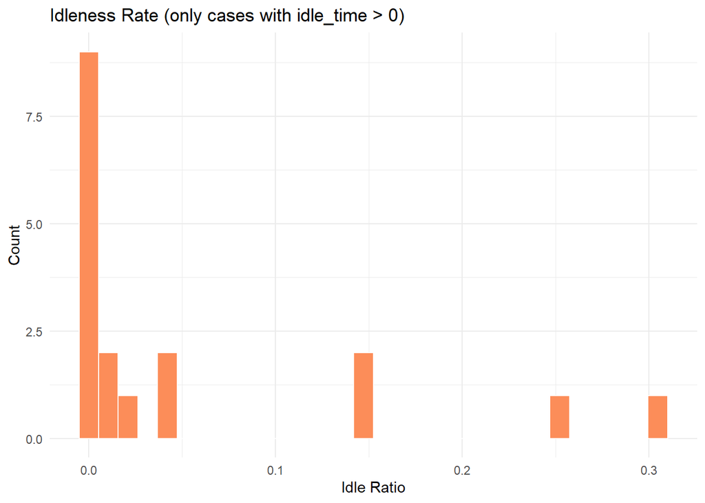

```r
garment_df <- garment_df %>%
  mutate(idle_ratio = idle_time / (idle_time + smv + over_time))

ggplot(filter(garment_df, idle_time > 0.0), aes(x = idle_ratio)) +
  geom_histogram(bins = 30, fill = "#fc8d59", color = "white") +
  labs(
    title = "Idleness Rate (only cases with idle_time > 0)",
    x = "Idle Ratio",
    y = "Count"
  ) +
  theme_minimal()
```

The distribution shows that even among the few cases where idle time is recorded, most have an extremely low idleness rate (close to 0). Only a few records reach higher values (above 0.2 or 0.3), but these are exceptional. In conclusion, idleness is very rare, and when it does occur, it represents a small portion of the total time. This also reinforces what was observed in the correlation analysis: any occurrence of idleness negatively impacts productivity, even if it happens infrequently.

**3.Surplus Value Rate:**

This variable is inspired by the Marxist concept of surplus value, adapted to the context of labour productivity data. It aims to measure how much “apparent surplus value” a worker generates, calculated as:

- The value produced (`actual_productivity * smv`)
- Plus the unplanned extra work (`over_time`)
- Minus the extra remuneration received (incentives divided by 10 as an approximate scale)

All of this is compared to the necessary work (`smv * no_of_workers`) to obtain a relative rate of value extraction.

This operationalization closely follows Marx’s original formulation of the surplus value rate as the key measure of exploitation (Marx, 1867), and finds contemporary application in case studies such as the Tricontinental Institute’s (2019) analysis of the iPhone production chain. The metric questions whether incentives truly compensate for the extra effort or if they mask unpaid labour. It is particularly relevant in work environments where bonuses may not fully reflect the actual effort.

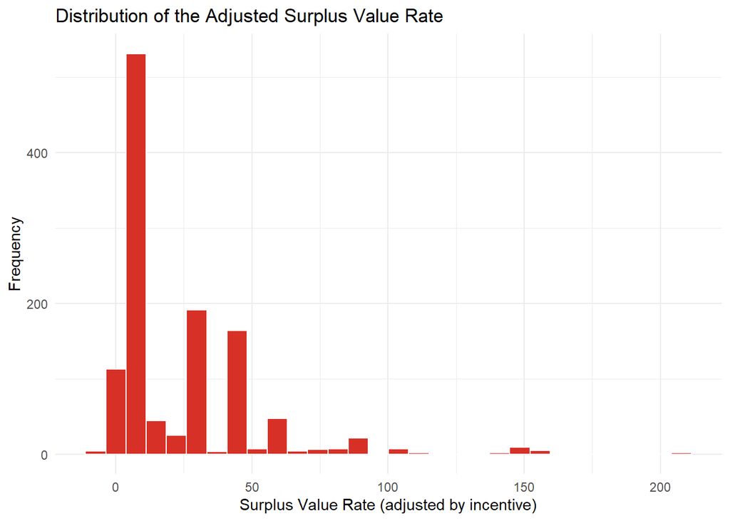

```r
# Calculate adjusted surplus value rate
garment_df <- garment_df %>%
  mutate(
    necessary_labour = smv * no_of_workers,
    apparent_surplus_value = (over_time + (actual_productivity * smv) - incentive / 10),
    adjusted_surplus_rate = apparent_surplus_value / necessary_labour
  )

# Histogram of the adjusted surplus value rate
ggplot(garment_df, aes(x = adjusted_surplus_rate)) +
  geom_histogram(fill = "#d73027", bins = 30, color = "white") +
  labs(
    title = "Distribution of the Adjusted Surplus Value Rate",
    x = "Surplus Value Rate (adjusted by incentive)",
    y = "Frequency"
  ) +
  theme_minimal()
```

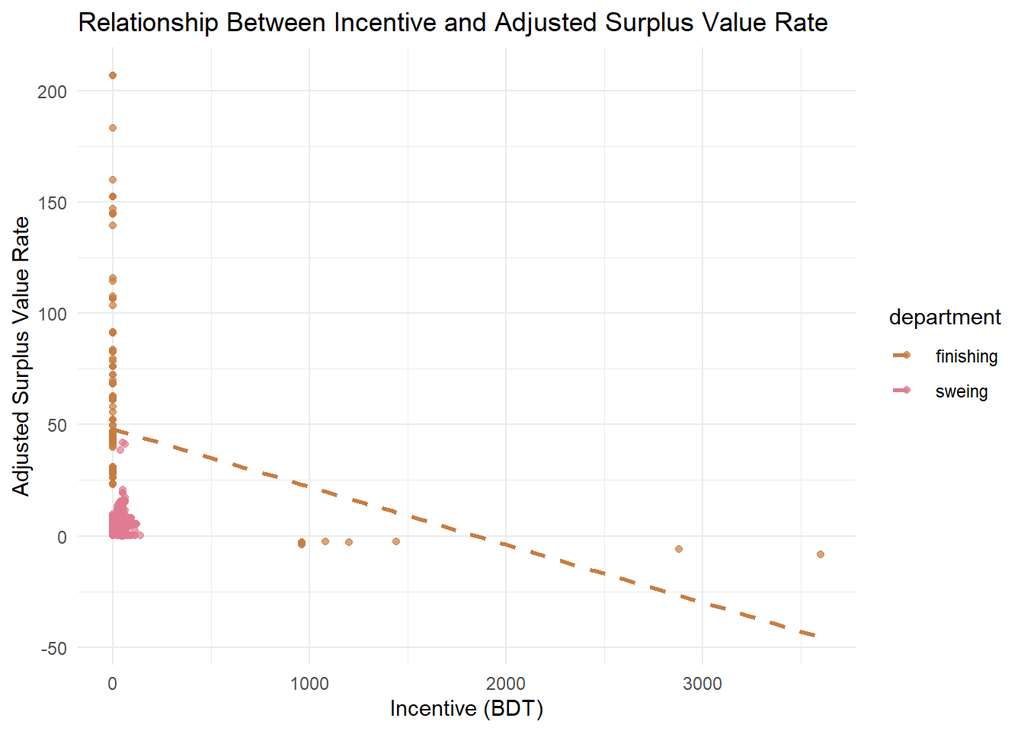

```r
# Relationship between incentive and surplus value
ggplot(garment_df, aes(x = incentive, y = adjusted_surplus_rate, color = department)) +
  geom_point(alpha = 0.7) +
  geom_smooth(method = "lm", se = FALSE, linetype = "dashed") +
  scale_color_manual(values = my_palette) +
  labs(
    title = "Relationship Between Incentive and Adjusted Surplus Value Rate",
    x = "Incentive (BDT)",
    y = "Adjusted Surplus Value Rate"
  ) +
  theme_minimal()
```

The histogram shows a strongly right-skewed distribution, with most values concentrated between 0 and 50, though some cases reach very high values, even over 200. This indicates that, in most observations, the surplus value generated, that is, the value produced beyond the necessary work, is several times higher than the effort estimated in the `SMV` for each worker. In conclusion, most workers generate more value than they are compensated for (even adjusting for incentives), pointing to significant surplus value extraction in the observed production system.

The other graph reveals a negative trend between economic incentives and the adjusted surplus value rate: as incentives increase, the relative surplus value generated by workers tends to decrease. This relationship is especially visible in the finishing department, where higher incentives seem to act as a compensatory mechanism for the additional effort, thus reducing relative exploitation.

### 2.1.4 Outliers

To better understand the distribution and variability of the numeric variables in the dataset, an outlier analysis was performed using boxplots.

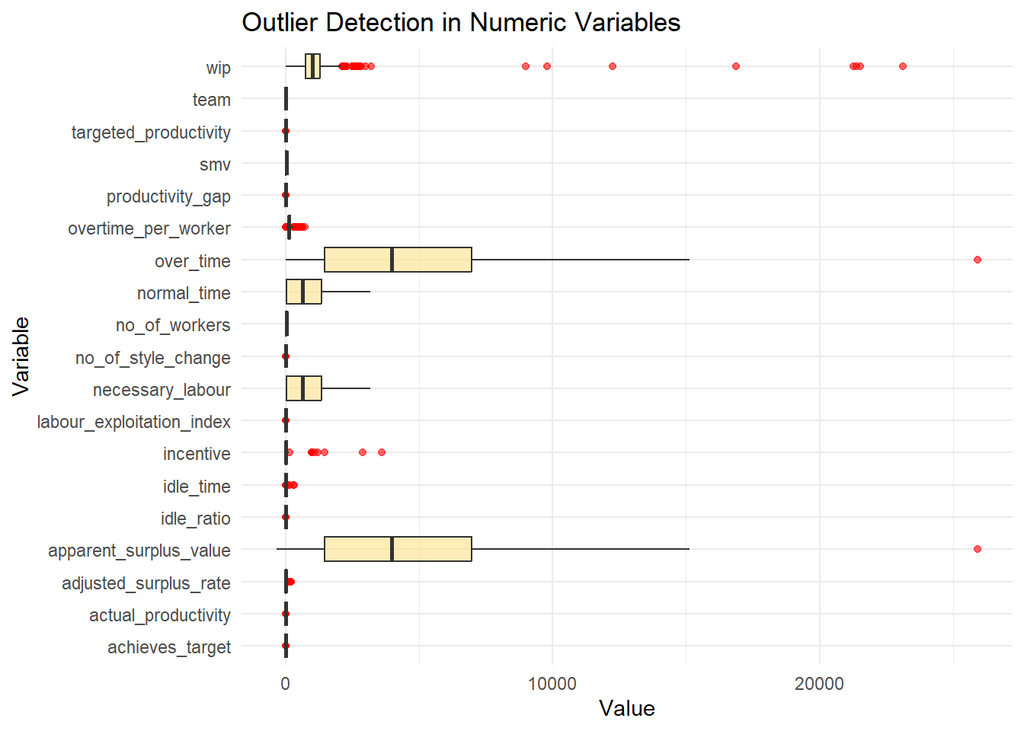

```r
# For easier plotting
garment_long <- garment_df %>%
  pivot_longer(cols = where(is.numeric), names_to = "variable", values_to = "value")

# Create boxplots to detect outliers
ggplot(garment_long, aes(x = variable, y = value)) +
  geom_boxplot(outlier.color = "red", fill = "#fee08b", alpha = 0.6) +
  coord_flip() +
  labs(title = "Outlier Detection in Numeric Variables",
       x = "Variable", y = "Value") +
  theme_minimal()
```

To facilitate comparison across variables with different scales, all numeric features were standardized and visualized using boxplots. This allows for a clearer detection of outliers and variance differences, supporting future decisions regarding feature selection, normalization, or transformation before modelling.

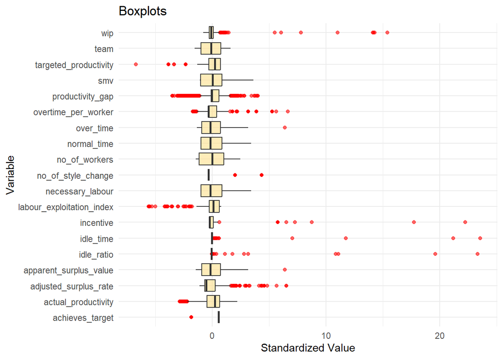

```r
# For easier plotting
garment_long_scaled <- garment_df %>%
  dplyr::select(where(is.numeric)) %>%
  mutate(across(everything(), scale)) %>%
  pivot_longer(cols = everything(), names_to = "variable", values_to = "value")

# Create boxplots to detect outliers with standardized variables
ggplot(garment_long_scaled, aes(x = variable, y = value)) +
  geom_boxplot(outlier.color = "red", fill = "#fee08b", alpha = 0.6) +
  coord_flip() +
  labs(title = "Boxplots",
       x = "Variable", y = "Standardized Value") +
  theme_minimal()
```

Since I do not want to reduce the number of observations or discard valuable data, I opt for an approach of transformation and recoding of outliers, rather than removing them.

- **Logarithmic transformations (`log1p`)** on strongly skewed variables (`wip`, `over_time`, `incentive`) to reduce the magnitude of extreme values and improve the symmetry of their distributions.
- **Winsorization of extreme values** in `apparent_surplus_value` and `adjusted_surplus_rate`, limiting values below the 1st percentile and above the 99th percentile. This allows for retaining all observations while only smoothing the impact of the most extreme values.
- **Binarization of idleness variables** (`idle_time`), which mostly had zeros, transforming them into indicators of presence/absence (0/1). This facilitates their incorporation as explanatory variables without introducing noise.

```r
# 1. Log transformation
garment_df <- garment_df %>%
  mutate(
    log_incentive = log1p(incentive),
    log_wip = log1p(wip),
    log_over_time = log1p(over_time)
  )

# 2. Winsorization
winsorize <- function(x, lower = 0.01, upper = 0.99) {
  qnt <- quantile(x, probs = c(lower, upper), na.rm = TRUE)
  x[x < qnt[1]] <- qnt[1]
  x[x > qnt[2]] <- qnt[2]
  return(x)
}

garment_df <- garment_df %>%
  mutate(
    adjusted_surplus_rate_wins = winsorize(adjusted_surplus_rate),
    apparent_surplus_value = winsorize(apparent_surplus_value)
  )


# 3. Binarization
garment_df <- garment_df %>%
  mutate(
    idle_time_bin = if_else(idle_time > 0, 1, 0))
```

### 2.1.5 Feature Selection and Principal Component Analysis

Principal Component Analysis (PCA) is employed as an exploratory tool to identify the variables that most significantly contribute to the variability within the dataset. PCA allows for dimensionality reduction and the discovery of latent patterns, highlighting the variables that account for the greatest proportion of the observed variance. This not only provides a clearer understanding of the relationships among variables but also offers valuable insights for the feature selection process.

```r
# Selection of numeric variables
num_vars_final <- c("actual_productivity", "targeted_productivity",
                    "smv", "over_time", "incentive", "no_of_style_change",
                    "no_of_workers", "log_incentive", "log_wip",
                    "log_over_time", "adjusted_surplus_rate_wins",
                    "apparent_surplus_value", "idle_time_bin",
                    "labour_exploitation_index",
                    "idle_ratio")

data_pca <- garment_df %>%
  dplyr::select(all_of(num_vars_final)) %>%
  na.omit()

# Scaling
data_scaled <- scale(data_pca)

# PCA
pca_result <- prcomp(data_scaled, center = TRUE, scale. = TRUE)

# Explained variance
summary(pca_result)
```

```
## Importance of components:
##                           PC1    PC2    PC3     PC4     PC5     PC6     PC7
## Standard deviation     2.1987 1.5646 1.3952 1.10629 1.00289 0.98061 0.83559
## Proportion of Variance 0.3223 0.1632 0.1298 0.08159 0.06705 0.06411 0.04655
## Cumulative Proportion  0.3223 0.4855 0.6153 0.69685 0.76390 0.82801 0.87456
##                            PC8     PC9    PC10    PC11    PC12    PC13    PC14
## Standard deviation     0.72308 0.67013 0.64617 0.48146 0.39397 0.27002 0.14951
## Proportion of Variance 0.03486 0.02994 0.02784 0.01545 0.01035 0.00486 0.00149
## Cumulative Proportion  0.90941 0.93935 0.96719 0.98264 0.99299 0.99785 0.99934
##                           PC15
## Standard deviation     0.09965
## Proportion of Variance 0.00066
## Cumulative Proportion  1.00000
```

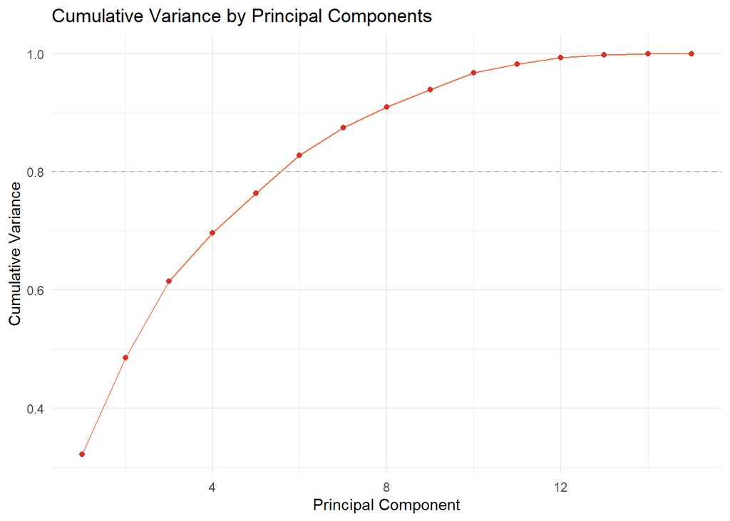

```r
# Scree plot
var_explained <- pca_result$sdev^2 / sum(pca_result$sdev^2)
var_cumulative <- cumsum(var_explained)

scree_df <- data.frame(
  PC = 1:length(var_explained),
  Variance = var_explained,
  Cumulative_Variance = var_cumulative
)

ggplot(scree_df, aes(x = PC, y = Cumulative_Variance)) +
  geom_line(color = "#f46d43") +
  geom_point(color = "#d73027") +
  geom_hline(yintercept = 0.8, linetype = "dashed", color = "grey") +
  theme_minimal() +
  labs(title = "Cumulative Variance by Principal Components",
       x = "Principal Component",
       y = "Cumulative Variance")
```

The PCA analysis shows that the first three principal components capture more than 60% of the variance in the data (PC1: 32%, PC2: 16%, PC3: 13%). Beyond PC7, each additional component adds only a small portion of variance. This suggests that dimensionality can be reduced to 6 or 7 principal components while still retaining most of the variance in the dataset.

For further information of variables importances:

```r
# Loadings
loadings <- pca_result$rotation

# check the absolute loadings in PC1 and PC2
abs_loadings <- abs(loadings[, c("PC1", "PC2")])

# Sum importance in PC1 + PC2
importance_total <- rowSums(abs_loadings)

# Create an ordered dataframe
importance_df <- data.frame(
  Variable = rownames(abs_loadings),
  Importance = importance_total
) %>%
  arrange(desc(Importance))

print(importance_df)
```

```
##                                              Variable Importance
## log_over_time                           log_over_time 0.68971667
## labour_exploitation_index   labour_exploitation_index 0.67519347
## apparent_surplus_value         apparent_surplus_value 0.64852536
## over_time                                   over_time 0.64378474
## adjusted_surplus_rate_wins adjusted_surplus_rate_wins 0.52564536
## no_of_workers                           no_of_workers 0.51220614
## smv                                               smv 0.49890400
## log_incentive                           log_incentive 0.41269927
## idle_ratio                                 idle_ratio 0.37904504
## idle_time_bin                           idle_time_bin 0.37015421
## no_of_style_change                 no_of_style_change 0.34841859
## incentive                                   incentive 0.20860101
## log_wip                                       log_wip 0.17741134
## actual_productivity               actual_productivity 0.13107451
## targeted_productivity           targeted_productivity 0.07421348
```

Given the size and complexity of the dataset, as well as the choice of modelling algorithms, a formal multicollinearity assessment, such as calculating the variance inflation factor (VIF) was ultimately not performed. This decision is supported by the use of Random Forest and XGBoost, well-known for their robustness to multicollinearity. These algorithms are capable of effectively handling correlated predictors by reducing their influence during the training process. As a result, even in the presence of correlated variables, the models can still provide stable and reliable predictions without the need for explicit collinearity diagnostics.

#### 2.1.5.1 Final selection

Considering the classification problem at hand, determining whether teams achieve their expected productivity, combined with the correlation matrix, PCA and empirical performance in predictive modelling the following variables are selected:

Variables directly related to productivity outcomes, such as actual_productivity, targeted_productivity or adjusted_surplus_rate_wins, are not included as features in the predictive models, as they are conceptually and statistically linked to the target variable. Including them would lead to information leakage and artificially inflated performance metrics, compromising the validity of the results.

The final set of predictors includes:

```r
final_vars <- garment_df %>%  dplyr::select("date","log_over_time", "department",
                 "smv", "no_of_style_change", "log_incentive", "log_wip",
                 "achieves_target", "no_of_workers", "idle_ratio")
```

```r
vars_df <- data.frame(
  Variable = c(
    "date", "log_over_time", "department", "smv", "no_of_style_change",
    "log_incentive", "log_wip", "no_of_workers", "idle_ratio", "achieves_target"
  ),
  Description = c(
    "Observation date (captures temporal effects and seasonality)",
    "Log-transformed accumulated overtime (workload indicator)",
    "Department (categorical: sewing or finishing)",
    "Standard Minute Value (task complexity and planning)",
    "Number of style changes (workflow variability)",
    "Log-transformed economic incentives (motivation/proxy for bonuses)",
    "Log-transformed Work In Progress (bottlenecks/flow indicator)",
    "Number of workers in the team (team size/structure)",
    "Proportion of idle time over total available time (inefficiency indicator)",
    "Target variable: did the team achieve expected productivity? (1=Yes, 0=No)"
  ),
  Type = c(
    "Date", "Numeric (log)", "Categorical", "Numeric", "Numeric",
    "Numeric (log)", "Numeric (log)", "Numeric", "Numeric", "Binary"
  ),
  stringsAsFactors = FALSE
)

ft_vars <- flextable(vars_df) %>%
  set_header_labels(
    Variable = "Variable",
    Description = "Description",
    Type = "Type"
  ) %>%
  add_header_lines("Description of Variables Used in Final Predictive modelling") %>%
  autofit() %>%
  align(align = "left", part = "all") %>%
  theme_box()

ft_vars
```

| Description of Variables Used in Final Predictive modelling Variable | Description of Variables Used in Final Predictive modelling Description | Description of Variables Used in Final Predictive modelling Type |
| --- | --- | --- |
| date | Observation date (captures temporal effects and seasonality) | Date |
| log_over_time | Log-transformed accumulated overtime (workload indicator) | Numeric (log) |
| department | Department (categorical: sewing or finishing) | Categorical |
| smv | Standard Minute Value (task complexity and planning) | Numeric |
| no_of_style_change | Number of style changes (workflow variability) | Numeric |
| log_incentive | Log-transformed economic incentives (motivation/proxy for bonuses) | Numeric (log) |
| log_wip | Log-transformed Work In Progress (bottlenecks/flow indicator) | Numeric (log) |
| no_of_workers | Number of workers in the team (team size/structure) | Numeric |
| idle_ratio | Proportion of idle time over total available time (inefficiency indicator) | Numeric |
| achieves_target | Target variable: did the team achieve expected productivity? (1=Yes, 0=No) | Binary |

# 3 Models

### 3.0.1 XGboost

#### 3.0.1.1 Cross Validation

Group-based cross-validation based on the team variable is not performed because the team identifier does not correspond to a consistent, well-defined grouping across the dataset. As demonstrated in the exploratory analysis, teams are not present for the same number of days, and team composition can vary over time within each department. Therefore, stratifying or grouping by team during cross-validation would not ensure meaningful separation of observations or mitigate data leakage, as teams do not represent stable, temporally coherent entities.

Instead, a temporal split is applied to the dataset, preserving the chronological order of observations. This approach avoids look-ahead bias and more accurately simulates a real-world forecasting scenario, where only information available up to a given point in time can be used for prediction. By respecting the temporal structure, the analysis remains robust and better reflects the operational context of productivity forecasting in a manufacturing environment.

The data is split as follows:

- Training set: 2015-01-01 to 2015-02-15
- Validation set: 2015-02-16 to 2015-02-28
- Test set: 2015-03-01 to 2015-03-11

```r
set.seed(432)
# Split by time periods
train_data <- final_vars %>% filter(date >= as.Date("2015-01-01") & date <= as.Date("2015-02-15"))
val_data   <- final_vars %>% filter(date >= as.Date("2015-02-16") & date <= as.Date("2015-02-28"))
test_data  <- final_vars %>% filter(date >= as.Date("2015-03-01") & date <= as.Date("2015-03-11"))

# Show the results
cat(nrow(train_data), "train\n")
```

```
## 785 train
```

```r
cat(nrow(val_data),   "validation\n")
```

```
## 200 validation
```

```r
cat(nrow(test_data),  "test\n")
```

```
## 212 test
```

```r
table(train_data$achieves_target)
```

```
##
##   0   1
## 160 625
```

```r
table(val_data$achieves_target)
```

```
##
##   0   1
##  67 133
```

```r
table(test_data$achieves_target)
```

```
##
##   0   1
##  40 172
```

To develop the predictive model, I first transformed the datasets (train, validation, and test) into matrices suitable for XGBoost, excluding the target variable and the date. Next, I created xgb.DMatrix objects, which are optimized data structures for training with XGBoost, for each subset. I then defined a grid of hyperparameters to tune: the learning rate (eta), maximum tree depth (max_depth), and the number of boosting rounds (nrounds).

```r
set.seed(123)
# Prepare matrices for XGBoost
x_train <- model.matrix(achieves_target ~ . -1 -date, data = train_data)
y_train <- train_data$achieves_target

x_val <- model.matrix(achieves_target ~ . -1 -date, data = val_data)
y_val <- val_data$achieves_target

x_test <- model.matrix(achieves_target ~ . -1 -date, data = test_data)
y_test <- test_data$achieves_target

dtrain <- xgb.DMatrix(data = x_train, label = y_train)
dval <- xgb.DMatrix(data = x_val, label = y_val)
dtest <- xgb.DMatrix(data = x_test, label = y_test)

# Define parameter grid and train models
param_grid <- expand.grid(
  eta = c(0.01, 0.1),
  max_depth = c(3, 6),
  nrounds = c(100, 200)
)

scale_pos_weight <- sum(y_train == 0) / sum(y_train == 1)
```

For each combination of hyperparameters, an XGBoost model is trained using the training set. Its performance is evaluated on the validation set by calculating the Area Under the Curve (AUC). The model that achieves the highest AUC on the validation set is selected as the final model.

```r
best_auc <- 0
best_model <- NULL

for(i in 1:nrow(param_grid)) {
  param <- list(
    objective = "binary:logistic",
    eta = param_grid$eta[i],
    max_depth = param_grid$max_depth[i],
    eval_metric = "auc"
  )

  model <- xgb.train(
    params = param,
    data = dtrain,
    nrounds = param_grid$nrounds[i],
    watchlist = list(val = dval),
    verbose = 0
  )

  pred_val <- predict(model, dval)
  auc <- roc(y_val, pred_val)$auc

  if(auc > best_auc) {
    best_auc <- auc
    best_model <- model
  }
}
```

This procedure ensures that the model is not only trained on historical data but is also optimized and validated on a temporally subsequent set, preventing information leakage. The use of a grid search for hyperparameter tuning a make the approach robust By optimizing for AUC on the validation set, I prioritize the model’s ability to distinguish between classes, which is crucial given the imbalance in the outcome variable.

#### 3.0.1.2 Test and Evaluation

Now, the test set prediction and threshold optimization

```r
set.seed(134)
# Predice en test
pred_test <- predict(best_model, dtest)
cat("Length pred_test:", length(pred_test), "\n")
```

```
## Length pred_test: 212
```

```r
# Calculate the optimal threshold using ROC
roc_val <- roc(y_val, predict(best_model, dval))
thr_opt <- coords(roc_val, "best", ret = "threshold")[[1]]

cat("Optimal threshold:", thr_opt, "\n")
```

```
## Optimal threshold: 0.783585
```

```r
# Prediction
pred_class_opt <- ifelse(pred_test > thr_opt, 1, 0)

# Matrix
confusionMatrix(
  factor(pred_class_opt, levels = c(0, 1)),
  factor(y_test, levels = c(0, 1)),
  positive = "1"
)
```

```
## Confusion Matrix and Statistics
##
##           Reference
## Prediction   0   1
##          0  33  32
##          1   7 140
##
##                Accuracy : 0.816
##                  95% CI : (0.7572, 0.8658)
##     No Information Rate : 0.8113
##     P-Value [Acc > NIR] : 0.4722699
##
##                   Kappa : 0.5154
##
##  Mcnemar's Test P-Value : 0.0001215
##
##             Sensitivity : 0.8140
##             Specificity : 0.8250
##          Pos Pred Value : 0.9524
##          Neg Pred Value : 0.5077
##              Prevalence : 0.8113
##          Detection Rate : 0.6604
##    Detection Prevalence : 0.6934
##       Balanced Accuracy : 0.8195
##
##        'Positive' Class : 1
##
```

To optimize classification performance, the optimal decision threshold was determined using the ROC curve on the validation set. The “best” threshold maximizes both sensitivity and specificity, and this value was then applied to the test set probabilities to generate the final binary predictions.

- Sensitivity (Recall for class 1) is high at 0.814, indicating that the model correctly identifies 81.4% of the teams that meet or exceed the productivity target. This is crucial for ensuring that the majority of successful teams are recognized as such.
- Specificity (Recall for class 0) is also strong at 0.825, meaning the model correctly identifies 82.5% of the teams that do not achieve the productivity target. This demonstrates the model’s ability to detect underperforming teams and avoid false positives.
- Balanced accuracy is 0.820, reflecting robust overall performance in the presence of class imbalance. This metric ensures that both classes are treated fairly and that model performance is not inflated by the majority class.
- Overall accuracy stands at 0.816, indicating that just over 81% of all teams are correctly classified, regardless of class.
- The Kappa statistic of 0.52 suggests a moderate agreement between the model predictions and the true class labels, above what would be expected by chance.
- Positive Predictive Value (Precision for class 1) is very high (0.952), meaning that when the model predicts a team will achieve the productivity target, it is correct more than 95% of the time.
- Negative Predictive Value (for class 0) is 0.51, indicating that among teams predicted not to achieve the target, about 51% truly do not achieve it. This is expected in the context of an imbalanced dataset.

In summary, the model demonstrates excellent reliability in predicting which teams will meet productivity expectations and robust performance in identifying underperforming teams. The high precision for the positive class is particularly relevant for applications focused on recognizing high-performing teams, while balanced accuracy confirms that both classes are well captured by the model.

#### 3.0.1.3 Variable Importance

```r
# Variable Importance:
importance_matrix <- xgb.importance(model = best_model)
print(importance_matrix)
```

```
##                Feature        Gain       Cover  Frequency
##                 <char>       <num>       <num>      <num>
## 1:             log_wip 0.432541078 0.376830686 0.36172840
## 2:       log_incentive 0.195015132 0.190975098 0.10061728
## 3:                 smv 0.182440320 0.183853741 0.18641975
## 4:       log_over_time 0.096022832 0.134416901 0.18580247
## 5:       no_of_workers 0.079727045 0.073477059 0.12037037
## 6: departmentfinishing 0.010343762 0.009857992 0.02098765
## 7:  no_of_style_change 0.003909831 0.030588522 0.02407407
```

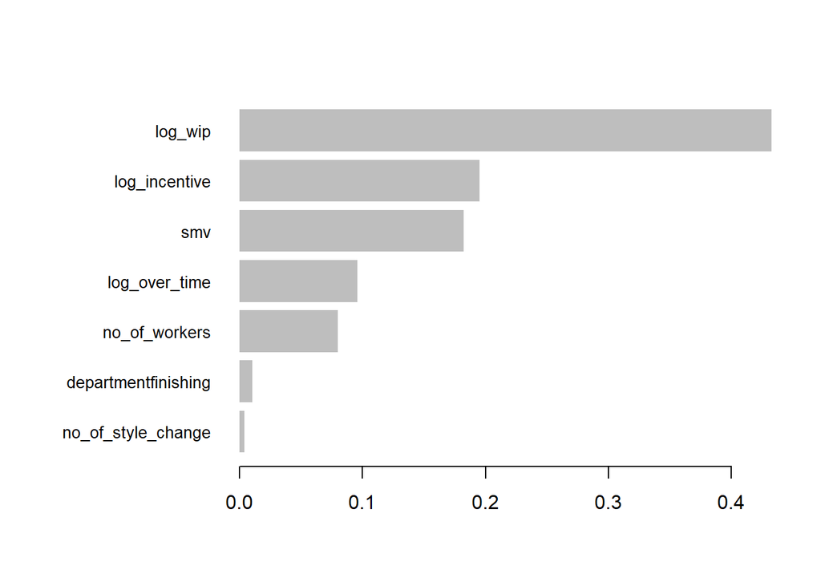

```r
xgb.plot.importance(importance_matrix, top_n = 10)
```

Other features, such as **log_over_time** (extra hours worked) and **no_of_workers** (team size), show moderate influence, suggesting they play a supporting role in determining productivity outcomes. Variables like **department** and **no_of_style_change** (the number of style changes) have relatively low importance, indicating that differences between departments or frequent style changes contribute less to the final classification.

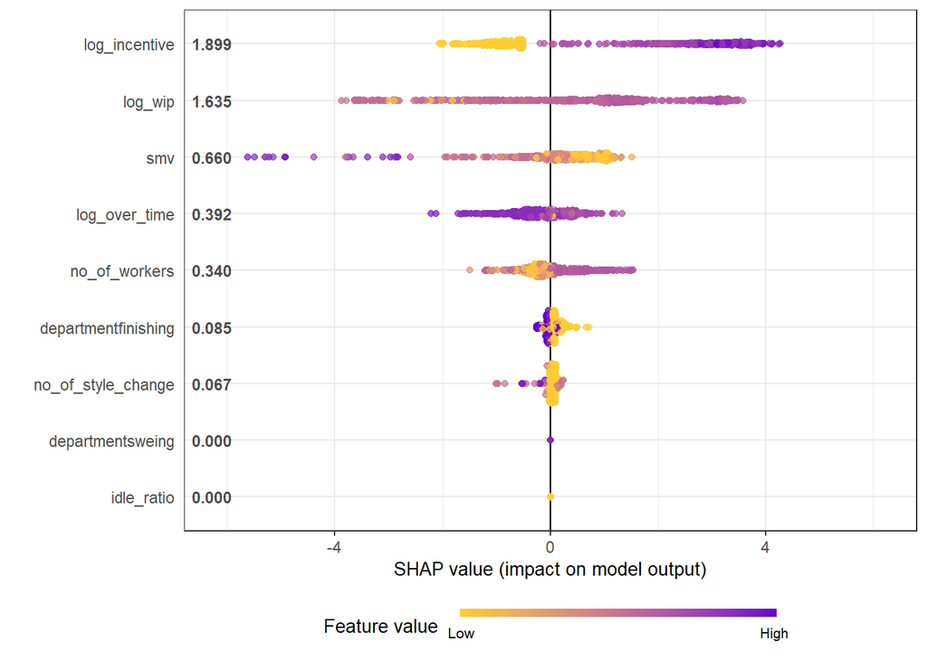

```r
#SHAP
shap_values <- shap.values(xgb_model = best_model, X_train = x_train)
shap_long <- shap.prep(shap_contrib = shap_values$shap_score, X_train = x_train)
shap.plot.summary(shap_long)
```

The SHAP value summary plot confirms these findings:

- **log_incentive** and **log_wip** both display wide ranges of SHAP values, highlighting their strong and non-linear influence on the prediction. Higher values of these variables are strongly associated with an increased probability of achieving the productivity target.
- **SMV** again appears as a relevant factor, supporting the conclusion that both economic and organizational factors drive productivity outcomes.

```r
#Department comparison
departments <- unique(test_data$department)
auc_deps <- sapply(departments, function(dep) {
  idx <- which(test_data$department == dep)
  y_dep <- y_test[idx]
  pred_dep <- pred_test[idx]
  roc(y_dep, pred_dep)$auc
})
df_auc <- data.frame(
  Departament = departments,
  AUC = round(auc_deps, 3)
)
print(df_auc)
```

```
##           Departament   AUC
## finishing   finishing 0.820
## sweing         sweing 0.857
```

Overall, the results make clear that **work in progress (WIP) and economic incentives are the most critical drivers of productivity achievement in this factory context**, closely followed by task complexity (SMV).

### 3.0.2 Random Forest

To cross-check and validate the robustness of the predictions obtained with XGBoost, an alternative model based on Random Forest was trained. The aim is to see whether this method can improve the predictive capacity in classifying cases where expected productivity is not achieved (class 0).

```r
set.seed(111)
# Prepare data for Random Forest
train_data_rf <- train_data
val_data_rf   <- val_data
test_data_rf  <- test_data

# Ensure the target variable is a factor
train_data_rf$achieves_target <- factor(train_data_rf$achieves_target, levels = c(0, 1))
val_data_rf$achieves_target   <- factor(val_data_rf$achieves_target, levels = c(0, 1))
test_data_rf$achieves_target  <- factor(test_data_rf$achieves_target, levels = c(0, 1))

# Calculate inverse class weights
class_weights <- as.numeric(table(train_data_rf$achieves_target))
names(class_weights) <- c(0,1)
classwt = c('0' = 1/class_weights[1], '1' = 1/class_weights[2])

# Alternatively, inverse proportions
tbl <- table(train_data_rf$achieves_target)
classwt <- c("0" = as.numeric(tbl["1"]) / as.numeric(tbl["0"]), "1" = 1)
print(classwt)
```

```
##       0       1
## 3.90625 1.00000
```

```r
# Train the Random Forest model
rf_model <- randomForest(
  achieves_target ~ . -date,
  data = train_data_rf,
  ntree = 500,
  mtry = floor(sqrt(ncol(train_data_rf) - 2)),
  importance = TRUE
)

# Probability predictions
val_prob <- predict(rf_model, val_data_rf, type = "prob")[,2]
test_prob <- predict(rf_model, test_data_rf, type = "prob")[,2]

# Find optimal threshold on validation set using ROC curve
roc_val <- roc(as.numeric(as.character(val_data_rf$achieves_target)), val_prob)
thr_opt <- coords(roc_val, "best", ret = "threshold")
thr_opt <- as.numeric(thr_opt)

# Final classification on test set using optimal threshold
test_pred_class <- ifelse(test_prob > thr_opt, 1, 0)
cm_rf <- confusionMatrix(
  factor(test_pred_class, levels = c(0,1)),
  factor(as.numeric(as.character(test_data_rf$achieves_target)), levels = c(0,1)),
  positive = "1"
)
print(cm_rf)
```

```
## Confusion Matrix and Statistics
##
##           Reference
## Prediction   0   1
##          0  27  23
##          1  13 149
##
##                Accuracy : 0.8302
##                  95% CI : (0.7727, 0.8781)
##     No Information Rate : 0.8113
##     P-Value [Acc > NIR] : 0.2733
##
##                   Kappa : 0.4939
##
##  Mcnemar's Test P-Value : 0.1336
##
##             Sensitivity : 0.8663
##             Specificity : 0.6750
##          Pos Pred Value : 0.9198
##          Neg Pred Value : 0.5400
##              Prevalence : 0.8113
##          Detection Rate : 0.7028
##    Detection Prevalence : 0.7642
##       Balanced Accuracy : 0.7706
##
##        'Positive' Class : 1
##
```

```r
# Calculate AUC on test set
auc <- roc(as.numeric(as.character(test_data_rf$achieves_target)), test_prob)
print(auc)
```

```
##
## Call:
## roc.default(response = as.numeric(as.character(test_data_rf$achieves_target)),     predictor = test_prob)
##
## Data: test_prob in 40 controls (as.numeric(as.character(test_data_rf$achieves_target)) 0) < 172 cases (as.numeric(as.character(test_data_rf$achieves_target)) 1).
## Area under the curve: 0.8666
```

The model demonstrates a particularly strong ability to correctly identify teams that achieve their productivity goals (high sensitivity and precision for class 1), which is valuable for recognizing and reinforcing effective practices. The balanced accuracy and high AUC values confirm the practical robustness of the model, while the slightly lower specificity reflects the trade-off often encountered in class-imbalanced problems: the priority of early identification of successful teams over minimizing false positives among underperformers.

- Accuracy: 83.0%. The model correctly classifies 83% of all teams, providing a solid overall performance.
- Sensitivity (Recall for class 1): 0.866. The model successfully identifies 86.6% of the teams that achieve their productivity targets, which is crucial for reliably detecting high-performing teams.
- Specificity (Recall for class 0): 0.675. This means that 67.5% of teams that do not achieve the target are correctly identified, which is somewhat lower but still provides useful information for targeting interventions.
- Balanced Accuracy: 0.771. This metric, averaging sensitivity and specificity, ensures that both classes are fairly evaluated even in the presence of class imbalance.
- Positive Predictive Value (Precision for class 1): 0.920. When the model predicts that a team will meet the productivity target, it is correct over 92% of the time.
- Negative Predictive Value (for class 0): 0.54. For teams predicted not to meet the target, just over half are truly underperforming, reflecting the challenge of imbalanced data but still supporting targeted improvement efforts.
- Kappa statistic: 0.49, indicating moderate agreement beyond chance.
- AUC (Area Under the ROC Curve): 0.867, which demonstrates strong overall discriminative capacity and aligns with best practices in binary classification.

Overall, these results validate the Random Forest model as a reliable tool for explaining and predicting productivity achievement, especially from the perspective of recognizing high-performing teams in an industrial context.

#### 3.0.2.1 Variable importance

```r
# Importance
importance_values <- importance(rf_model)
print(importance_values)
```

```
##                             0         1 MeanDecreaseAccuracy MeanDecreaseGini
## log_over_time       7.2535063 12.914817            18.811291        18.888604
## department          5.6302870 12.792615            15.502641         5.485453
## smv                21.8408306 16.921668            27.365017        38.961932
## no_of_style_change  0.3038152  8.438527             8.579099         2.542230
## log_incentive      26.7127787 42.478726            47.050209        31.581887
## log_wip            38.5104633 30.518908            40.528935        65.345337
## no_of_workers       7.4857894 13.473489            18.002098        19.679180
## idle_ratio         -7.1884515  2.345346            -3.802268         1.174863
```

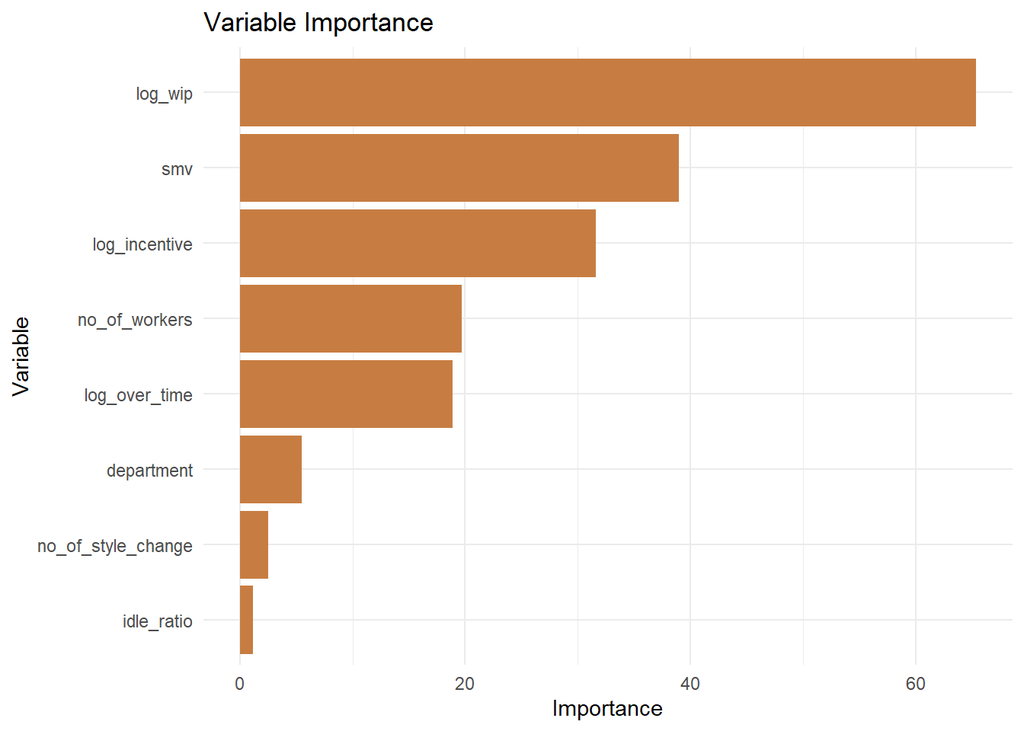

```r
# Data Frame
var_imp_df <- data.frame(
  Variable = rownames(importance_values),
  Importance = importance_values[, "MeanDecreaseGini"]
)
var_imp_df <- var_imp_df[order(var_imp_df$Importance, decreasing = TRUE), ]

# Plot
ggplot(var_imp_df, aes(x = reorder(Variable, Importance), y = Importance)) +
  geom_bar(stat = "identity", fill = "#c77d42") +
  coord_flip() +
  labs(
    title = "Variable Importance",
    x = "Variable",
    y = "Importance"
  ) +
  theme_minimal()
```

- log_wip (logarithm of Work in Progress) emerges as the most influential variable, indicating that higher volumes of ongoing work are strongly associated with productivity outcomes. Well-managed WIP is essential for maintaining steady production flow and meeting targets.
- log_incentive also demonstrates high importance, underscoring the decisive impact of economic incentives on team performance. Teams with stronger incentive structures are much more likely to achieve their productivity goals.
- smv (Standard Minute Value), a proxy for task complexity and planning requirements, is another critical predictor. This highlights the role of task difficulty and organization in shaping productivity.
- log_over_time (overtime hours) and no_of_workers (team size) also contribute significantly to the model. Teams with appropriate staffing levels and managed overtime are better positioned to meet targets, although excessive overtime does not always translate into higher performance.
- department displays moderate importance, suggesting that differences in organizational structure or work environment (e.g., sewing vs. finishing departments) have a secondary, yet still relevant, effect on productivity.
- no_of_style_change (workflow variability) and idle_ratio (proportion of idle time) show the lowest importance. This suggests that, within this modelling framework, frequent style changes and minor fluctuations in idle time have limited additional explanatory value.

Overall, the results confirm that productivity achievement is primarily driven by incentive systems, workflow load, and the complexity of tasks, rather than by minor workflow changes or idle time. This variable importance ranking is consistent with the findings from the XGBoost model, reinforcing the robustness of the identified predictors across different modelling approaches.

### 3.0.3 Model comparison table

```r
results <- data.frame(
  Model            = c("XGBoost", "Random Forest"),
  Sensitivity_1    = c(0.814, 0.866),
  Specificity_1    = c(0.825, 0.675),
  BalancedAccuracy = c(0.820, 0.771),
  AUC              = c(0.817, 0.867),
  Accuracy         = c(0.816, 0.830),
  Kappa            = c(0.515, 0.494)
)

results <- results %>% mutate(across(where(is.numeric), ~ round(.x, 2)))

ft <- flextable(results)
ft <- set_header_labels(
  ft,
  Model            = "Model",
  Sensitivity_1    = "Sensitivity (class 1)",
  Specificity_1    = "Specificity (class 1)",
  BalancedAccuracy = "Balanced Accuracy",
  AUC              = "AUC",
  Accuracy         = "Accuracy",
  Kappa            = "Kappa"
)
ft <- autofit(ft)
ft <- add_header_row(ft, values = "Model Comparison Table", colwidths = 7)
ft
```

[output not shown]

Both the XGBoost and Random Forest models demonstrated robust and reliable performance in classifying teams according to whether they achieved their expected productivity targets. XGBoost achieved an overall accuracy of 0.82 and a balanced accuracy of 0.82, with sensitivity at 0.81 and specificity at 0.82. The area under the ROC curve (AUC) reached 0.82, confirming strong discriminative power.

Random Forest performed similarly, with an accuracy of 0.83 and a balanced accuracy of 0.77, but achieved a higher sensitivity (0.87), indicating an even greater ability to correctly identify teams that met their productivity targets. However, its specificity was lower (0.68), reflecting a greater likelihood of false positives when predicting successful teams. The AUC for Random Forest was also high (0.87), suggesting excellent overall discrimination between classes.

The high sensitivity of both models means that the vast majority of teams achieving their targets were correctly identified, which is particularly valuable in practical settings where maximising the detection of successful cases is a priority. The slight trade-off in specificity, particularly in the Random Forest model, is acceptable given the emphasis on early detection and intervention for teams at risk of underperformance.

In summary, both machine learning approaches provided highly satisfactory and comparable results. Random Forest stands out for its higher sensitivity, making it especially useful for identifying high-performing teams. XGBoost, meanwhile, achieves slightly better balanced accuracy and specificity, offering a more even classification across both classes.

These findings reinforce the suitability of both algorithms for explanatory analysis in manufacturing environments with complex, imbalanced data. The results are consistent with benchmarks in the academic literature and provide a strong foundation for future interventions and improvements in productivity management.

Several enhancements could be explored in future analyses. First, applying temporal cross-validation for hyperparameter tuning would provide more robust and unbiased performance estimates, especially in time-dependent production environments. Additionally, incorporating new features, such as qualitative variables or external factors, may help explain residual variability in productivity outcomes. Advanced resampling techniques or cost-sensitive learning could further address class imbalance.

A particularly relevant area for improvement concerns the imputation of missing values for key variables such as Work in Progress (WIP, in this case log_wip). As the distribution of the imputed values was not fully aligned with the original, and the proportion of missing values was relatively high, future work could focus on refining the imputation methodology to better preserve the underlying structure of the data and reduce potential biases.

Finally, exploring more complex or hybrid modelling approaches, while maintaining interpretability, may yield additional improvements if larger datasets become available. These enhancements would strengthen the reliability and practical applicability of predictive models for productivity in industrial settings.

# 4 Conclusion

Through a combination of exploratory data analysis and interpretable machine learning models, this study has identified the principal factors underlying team productivity differences in a high-intensity manufacturing environment. Using real-world data from the Bangladeshi garment sector, the analysis provides nuanced insights into how organizational structure, incentive schemes, and operational practices interact to determine whether teams achieve their productivity targets.

Variable importance analyses, using both feature importance metrics and SHAP values, consistently highlighted that log_wip (work in progress) and log_incentive (economic incentives) are the most influential predictors of productivity achievement. Teams benefiting from higher economic incentives and better-managed workflows were significantly more likely to meet or exceed productivity targets. SMV (task complexity) also emerged as a key factor, whereas variables such as log_over_time and no_of_style_change played a lesser role, suggesting that overtime and workflow variability alone do not guarantee improved outcomes.

In summary, this study demonstrates that explainable machine learning models can not only classify productivity outcomes with high reliability, but, crucially, also uncover the underlying drivers of performance in complex, real-world manufacturing environments. These insights can directly inform targeted interventions and policy decisions aimed at improving productivity and working conditions in the industry.

# 5 Bibliography

Ahn, C., Lee, S., & Peña-Mora, F. (2013). A case study: Idle time ratio for construction equipment. Journal of Construction Engineering and Management, 139(5), 572–580.

Balla, I., Rahayu, S., & Jaya Purnama, J. (2021). Garment employee productivity prediction using Random Forest. Techno Nusa Mandiri: Journal of Computing and Information Technology, 18(1), 49–54.

Chan, J., & Siu, K. (2010). Analyzing exploitation: Excessive overtime and piece-rate work in Chinese export factories. Critical Asian Studies, 42(2), 167–190.

Marx, K. (1867). Capital: A critique of political economy (Vol. I, Ch. 9). Progress Publishers.

Obiedat, R., & Toubasi, S. (2022). A combined approach for predicting employees’ productivity based on ensemble machine learning methods. Informatica, 46(5), 49–58.

Patnaik, U. (1972). Class differentiation within the peasantry: An approach to the analysis of Indian agriculture. Economic and Political Weekly, 7(31/33), 1239–1245.

Tricontinental Institute for Social Research. (2019). The rate of exploitation: The case of the iPhone.

Abdullah Al Imran, Md Shamsur Rahim, & Tanvir Ahmed. (2021). Mining the productivity data of the garment industry. International Journal of Business Intelligence and Data Mining, 19(3), 319–342.